# The Success Equation: Predicting Start-up Success with Advanced Predictive Analytics

The Egyptian Russian unviversity - Faculty of Mangement, Economics, and Business technology

2024-06-01

```
##                  Name     ID
## 1 Abdelrahman Mahmoud 214117
## 2         Ganna Asaad 204115
## 3        Mohamed Atef 214067
## 4        Toka Alsayed 214091
```

# Introduction

The startup ecosystem is dynamic and challenging, where success hinges on various factors. Predictive analytics, particularly classification models, are essential tools for investors, entrepreneurs, and policymakers to assess startup potential. By leveraging historical data, these models classify startups into categories like ‘successful’ or ‘failed’ and provide insights into key success factors such as funding, market trends, and team dynamics. This project applies various classification techniques to a rich dataset of startups, aiming to identify the most accurate predictors of success. We will use algorithms like logistic regression, decision trees, and support vector machines, evaluating their performance with metrics such as accuracy, precision, recall, and F1-score, to uncover actionable insights for informed decision-making in the startup ecosystem.

# Objectives

1. To evaluate the performance of different classification models in predicting the success of startup companies based on historical data.
2. To identify key factors that significantly influence the likelihood of a startup’s success or failure.
3. To provide actionable insights for stakeholders in the startup ecosystem to make informed decisions regarding investments and strategy.

# Reading and exploring the dataset stucture

## **Import libraries**

```r
library(flexdashboard)
library(plotly)
library(tidyverse)
library(skimr)
library(naniar)
library(mice)
library(corrplot)
library(GGally)
library(ggfortify)
library(MASS)
library(glmnet)
library(dplyr)
library(ggplot2)
```

## **Reading the data set**

```r
startup.data <- read.csv("D:/ERU/Level 3/S2/Pridective/Proj/Class/archive/startup data.csv")
base_data<-startup.data
```

## **Data set structure**

```r
str(base_data)
```

```
## 'data.frame':    923 obs. of  49 variables:
##  $ Unnamed..0              : int  1005 204 1001 738 1002 379 195 875 16 846 ...
##  $ state_code              : chr  "CA" "CA" "CA" "CA" ...
##  $ latitude                : num  42.4 37.2 32.9 37.3 37.8 ...
##  $ longitude               : num  -71.1 -122 -117.2 -122.1 -122.4 ...
##  $ zip_code                : chr  "92101" "95032" "92121" "95014" ...
##  $ id                      : chr  "c:6669" "c:16283" "c:65620" "c:42668" ...
##  $ city                    : chr  "San Diego" "Los Gatos" "San Diego" "Cupertino" ...
##  $ Unnamed..6              : chr  "" "" "San Diego CA 92121" "Cupertino CA 95014" ...
##  $ name                    : chr  "Bandsintown" "TriCipher" "Plixi" "Solidcore Systems" ...
##  $ labels                  : int  1 1 1 1 0 0 1 1 1 1 ...
##  $ founded_at              : chr  "1/1/2007" "1/1/2000" "3/18/2009" "1/1/2002" ...
##  $ closed_at               : chr  "" "" "" "" ...
##  $ first_funding_at        : chr  "4/1/2009" "2/14/2005" "3/30/2010" "2/17/2005" ...
##  $ last_funding_at         : chr  "1/1/2010" "12/28/2009" "3/30/2010" "4/25/2007" ...
```

[output cut: 35 more lines]

## **Data set cardinality**

```r
sapply(base_data, function(x) length(unique(x)))
```

```
##               Unnamed..0               state_code                 latitude
##                      923                       35                      652
##                longitude                 zip_code                       id
##                      651                      382                      922
##                     city               Unnamed..6                     name
##                      221                      253                      922
##                   labels               founded_at                closed_at
##                        2                      217                      203
##         first_funding_at          last_funding_at   age_first_funding_year
##                      585                      680                      634
##    age_last_funding_year age_first_milestone_year  age_last_milestone_year
##                      756                      472                      586
##            relationships           funding_rounds        funding_total_usd
##                       41                        9                      505
##               milestones             state_code.1                    is_CA
##                        8                       36                        2
##                    is_NY                    is_MA                    is_TX
##                        2                        2                        2
##            is_otherstate            category_code              is_software
##                        2                       35                        2
##                   is_web                is_mobile            is_enterprise
##                        2                        2                        2
##           is_advertising            is_gamesvideo             is_ecommerce
##                        2                        2                        2
##               is_biotech            is_consulting         is_othercategory
##                        2                        2                        2
##                object_id                   has_VC                has_angel
##                      922                        2                        2
##               has_roundA               has_roundB               has_roundC
##                        2                        2                        2
##               has_roundD         avg_participants                is_top500
##                        2                       59                        2
##                   status
##                        2
```

```r
df <- base_data
```

# **Data Pre-processing**

## 1) Dropping unnecessory variables

```r
df <- base_data |> dplyr::select(-c('Unnamed..0', 'Unnamed..6', 'id', 'object_id','zip_code','state_code.1'))
```

## 2) Renaming variables

```r
names(df)
```

```
##  [1] "state_code"               "latitude"
##  [3] "longitude"                "city"
##  [5] "name"                     "labels"
##  [7] "founded_at"               "closed_at"
##  [9] "first_funding_at"         "last_funding_at"
## [11] "age_first_funding_year"   "age_last_funding_year"
## [13] "age_first_milestone_year" "age_last_milestone_year"
## [15] "relationships"            "funding_rounds"
## [17] "funding_total_usd"        "milestones"
## [19] "is_CA"                    "is_NY"
## [21] "is_MA"                    "is_TX"
## [23] "is_otherstate"            "category_code"
## [25] "is_software"              "is_web"
## [27] "is_mobile"                "is_enterprise"
## [29] "is_advertising"           "is_gamesvideo"
## [31] "is_ecommerce"             "is_biotech"
## [33] "is_consulting"            "is_othercategory"
## [35] "has_VC"                   "has_angel"
## [37] "has_roundA"               "has_roundB"
## [39] "has_roundC"               "has_roundD"
## [41] "avg_participants"         "is_top500"
## [43] "status"
```

```r
df <- df |> rename(
    age_at_ff = age_first_funding_year,
    age_at_lf = age_last_funding_year,
    age_at_fm = age_first_milestone_year,
    age_at_lm = age_last_milestone_year,
    partners = relationships,
    n_funding_rounds = funding_rounds
)
```

## 3) Changing Data types

```r
df$founded_at <- as.Date(df$founded_at, format="%m/%d/%Y")
df$closed_at <- as.Date(df$closed_at, format="%m/%d/%Y")
df$first_funding_at <- as.Date(df$first_funding_at, format="%m/%d/%Y")
df$last_funding_at <- as.Date(df$last_funding_at, format="%m/%d/%Y")
```

```r
# Convert variables from double to logical (binary)
df$has_roundA <- as.integer(df$has_roundA)
df$has_roundB <- as.integer(df$has_roundB)
df$has_roundC <- as.integer(df$has_roundC)
df$has_roundD <- as.integer(df$has_roundD)
```

## 4) Variables computation

- Combine binary variables into one categorical variable

```r
df$has_roundA <- as.logical(df$has_roundA)
df$has_roundB <- as.logical(df$has_roundB)
df$has_roundC <- as.logical(df$has_roundC)
df$has_roundD <- as.logical(df$has_roundD)

df <- df %>%
  mutate(fundingRounds = case_when(
    has_roundA & has_roundB & has_roundC & has_roundD ~ "Round A, B, C, and D",
    has_roundA & has_roundB & has_roundC ~ "Round A, B, and C",
    has_roundA & has_roundB & has_roundD ~ "Round A, B, and D",
    has_roundA & has_roundC & has_roundD ~ "Round A, C, and D",
    has_roundB & has_roundC & has_roundD ~ "Round B, C, and D",
    has_roundA & has_roundB ~ "Round A and B",
    has_roundA & has_roundC ~ "Round A and C",
    has_roundA & has_roundD ~ "Round A and D",
    has_roundB & has_roundC ~ "Round B and C",
    has_roundB & has_roundD ~ "Round B and D",
    has_roundC & has_roundD ~ "Round C and D",
    has_roundA ~ "Round A",
    has_roundB ~ "Round B",
    has_roundC ~ "Round C",
    has_roundD ~ "Round D",
    TRUE ~ "No rounds"
  ))
```

- Reducing the large values of the variable funding_total_usd by transforming to its log

```r
df <- df|> mutate(funding_total_usd = log(funding_total_usd))
```

## 5) Explore and Handle Missing Data

summarization of the data

```r
skim(df)
```

Data summary

| Name | df |
| --- | --- |
| Number of rows | 923 |
| Number of columns | 44 |
| _______________________ |  |
| Column type frequency: |  |
| character | 6 |
| Date | 4 |
| logical | 4 |
| numeric | 30 |
| ________________________ |  |
| Group variables | None |

**Variable type: character**

| skim_variable | n_missing | complete_rate | min | max | empty | n_unique | whitespace |
| --- | --- | --- | --- | --- | --- | --- | --- |
| state_code | 0 | 1 | 2 | 2 | 0 | 35 | 0 |
| city | 0 | 1 | 2 | 19 | 0 | 221 | 0 |
| name | 0 | 1 | 3 | 39 | 0 | 922 | 0 |
| category_code | 0 | 1 | 3 | 16 | 0 | 35 | 0 |
| status | 0 | 1 | 6 | 8 | 0 | 2 | 0 |
| fundingRounds | 0 | 1 | 7 | 20 | 0 | 16 | 0 |

**Variable type: Date**

| skim_variable | n_missing | complete_rate | min | max | median | n_unique |
| --- | --- | --- | --- | --- | --- | --- |
| founded_at | 0 | 1.00 | 1984-01-01 | 2013-04-16 | 2006-01-01 | 217 |
| closed_at | 588 | 0.36 | 2001-01-01 | 2013-10-30 | 2012-02-17 | 202 |
| first_funding_at | 0 | 1.00 | 2000-01-01 | 2013-11-20 | 2007-09-01 | 585 |
| last_funding_at | 0 | 1.00 | 2001-01-01 | 2013-11-20 | 2009-12-16 | 680 |

**Variable type: logical**

| skim_variable | n_missing | complete_rate | mean | count |
| --- | --- | --- | --- | --- |
| has_roundA | 0 | 1 | 0.51 | TRU: 469, FAL: 454 |
| has_roundB | 0 | 1 | 0.39 | FAL: 561, TRU: 362 |
| has_roundC | 0 | 1 | 0.23 | FAL: 708, TRU: 215 |
| has_roundD | 0 | 1 | 0.10 | FAL: 831, TRU: 92 |

**Variable type: numeric**

| skim_variable | n_missing | complete_rate | mean | sd | p0 | p25 | p50 | p75 | p100 | hist |
| --- | --- | --- | --- | --- | --- | --- | --- | --- | --- | --- |
| latitude | 0 | 1.00 | 38.52 | 3.74 | 25.75 | 37.39 | 37.78 | 40.73 | 59.34 | ▁▇▅▁▁ |
| longitude | 0 | 1.00 | -103.54 | 22.39 | -122.76 | -122.20 | -118.37 | -77.21 | 18.06 | ▇▅▁▁▁ |
| labels | 0 | 1.00 | 0.65 | 0.48 | 0.00 | 0.00 | 1.00 | 1.00 | 1.00 | ▅▁▁▁▇ |
| age_at_ff | 0 | 1.00 | 2.24 | 2.51 | -9.05 | 0.58 | 1.45 | 3.58 | 21.90 | ▁▇▃▁▁ |
| age_at_lf | 0 | 1.00 | 3.93 | 2.97 | -9.05 | 1.67 | 3.53 | 5.56 | 21.90 | ▁▇▇▁▁ |
| age_at_fm | 152 | 0.84 | 3.06 | 2.98 | -14.17 | 1.00 | 2.52 | 4.69 | 24.68 | ▁▃▇▁▁ |
| age_at_lm | 152 | 0.84 | 4.75 | 3.21 | -7.01 | 2.41 | 4.48 | 6.75 | 24.68 | ▁▇▅▁▁ |
| partners | 0 | 1.00 | 7.71 | 7.27 | 0.00 | 3.00 | 5.00 | 10.00 | 63.00 | ▇▂▁▁▁ |
| n_funding_rounds | 0 | 1.00 | 2.31 | 1.39 | 1.00 | 1.00 | 2.00 | 3.00 | 10.00 | ▇▃▁▁▁ |
| funding_total_usd | 0 | 1.00 | 15.75 | 1.81 | 9.31 | 14.82 | 16.12 | 17.02 | 22.46 | ▁▂▇▂▁ |
| milestones | 0 | 1.00 | 1.84 | 1.32 | 0.00 | 1.00 | 2.00 | 3.00 | 8.00 | ▇▇▁▁▁ |
| is_CA | 0 | 1.00 | 0.53 | 0.50 | 0.00 | 0.00 | 1.00 | 1.00 | 1.00 | ▇▁▁▁▇ |
| is_NY | 0 | 1.00 | 0.11 | 0.32 | 0.00 | 0.00 | 0.00 | 0.00 | 1.00 | ▇▁▁▁▁ |
| is_MA | 0 | 1.00 | 0.09 | 0.29 | 0.00 | 0.00 | 0.00 | 0.00 | 1.00 | ▇▁▁▁▁ |
| is_TX | 0 | 1.00 | 0.05 | 0.21 | 0.00 | 0.00 | 0.00 | 0.00 | 1.00 | ▇▁▁▁▁ |
| is_otherstate | 0 | 1.00 | 0.22 | 0.42 | 0.00 | 0.00 | 0.00 | 0.00 | 1.00 | ▇▁▁▁▂ |
| is_software | 0 | 1.00 | 0.17 | 0.37 | 0.00 | 0.00 | 0.00 | 0.00 | 1.00 | ▇▁▁▁▂ |
| is_web | 0 | 1.00 | 0.16 | 0.36 | 0.00 | 0.00 | 0.00 | 0.00 | 1.00 | ▇▁▁▁▂ |
| is_mobile | 0 | 1.00 | 0.09 | 0.28 | 0.00 | 0.00 | 0.00 | 0.00 | 1.00 | ▇▁▁▁▁ |
| is_enterprise | 0 | 1.00 | 0.08 | 0.27 | 0.00 | 0.00 | 0.00 | 0.00 | 1.00 | ▇▁▁▁▁ |
| is_advertising | 0 | 1.00 | 0.07 | 0.25 | 0.00 | 0.00 | 0.00 | 0.00 | 1.00 | ▇▁▁▁▁ |
| is_gamesvideo | 0 | 1.00 | 0.06 | 0.23 | 0.00 | 0.00 | 0.00 | 0.00 | 1.00 | ▇▁▁▁▁ |
| is_ecommerce | 0 | 1.00 | 0.03 | 0.16 | 0.00 | 0.00 | 0.00 | 0.00 | 1.00 | ▇▁▁▁▁ |
| is_biotech | 0 | 1.00 | 0.04 | 0.19 | 0.00 | 0.00 | 0.00 | 0.00 | 1.00 | ▇▁▁▁▁ |
| is_consulting | 0 | 1.00 | 0.00 | 0.06 | 0.00 | 0.00 | 0.00 | 0.00 | 1.00 | ▇▁▁▁▁ |
| is_othercategory | 0 | 1.00 | 0.32 | 0.47 | 0.00 | 0.00 | 0.00 | 1.00 | 1.00 | ▇▁▁▁▃ |
| has_VC | 0 | 1.00 | 0.33 | 0.47 | 0.00 | 0.00 | 0.00 | 1.00 | 1.00 | ▇▁▁▁▃ |
| has_angel | 0 | 1.00 | 0.25 | 0.44 | 0.00 | 0.00 | 0.00 | 1.00 | 1.00 | ▇▁▁▁▃ |
| avg_participants | 0 | 1.00 | 2.84 | 1.87 | 1.00 | 1.50 | 2.50 | 3.80 | 16.00 | ▇▂▁▁▁ |
| is_top500 | 0 | 1.00 | 0.81 | 0.39 | 0.00 | 1.00 | 1.00 | 1.00 | 1.00 | ▂▁▁▁▇ |

Explore missing data

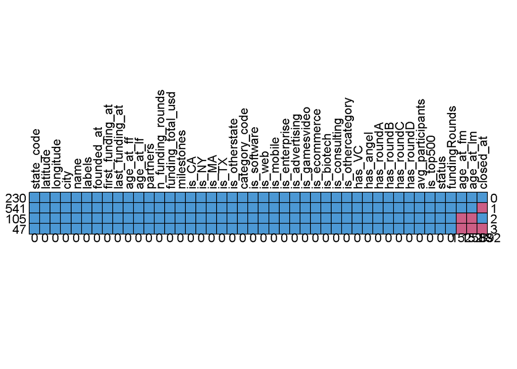

```r
options(repr.plot.width=50, repr.plot.height=30) # Adjust plot size
par(cex.main=9, cex.axis=9, cex.lab=9) # Maximize font size
miss_chart<-md.pattern(df, rotate.names = TRUE)
```

- replace NA with zero (meaning that the company has no milestones)

```r
df <- df |>
  mutate(age_at_fm = replace_na(age_at_fm, 0),
        age_at_lm = replace_na(age_at_lm, 0))
```

## 6) Handle Negative Values of age variables:

- Explore the negatives in the variables: age_at_fm and age_at_lm

```r
negative_counts <- df |>
  summarize(
    age_at_fm = sum(age_at_fm < 0, na.rm = TRUE),
    age_at_lm = sum(age_at_lm < 0, na.rm = TRUE)
  )

# Calculate the total number of rows
total_rows <- nrow(df)

# Calculate the percentage of records with negative values
negative_percentage <- negative_counts |>
  mutate(
    age_at_fm = (age_at_fm / total_rows) * 100,
    age_at_lm = (age_at_lm / total_rows) * 100
  )

# Print the results
negative_counts
```

```
##   age_at_fm age_at_lm
## 1        46        12
```

```r
negative_percentage
```

```
##   age_at_fm age_at_lm
## 1  4.983749  1.300108
```

```r
df <-df |>
  filter(age_at_fm >= 0, age_at_lm >= 0)
```

- Explore the negatives in the variables: age_at_ff and age_at_lf

negative values in age first funding indicate that the fund that have been taken is before opening the company so the age of the company was zero

```r
negative_counts <- df |>
  summarize(
    age_at_ff = sum(age_at_ff < 0, na.rm = TRUE),
    age_at_lf = sum(age_at_lf < 0, na.rm = TRUE)
  )

# Calculate the total number of rows
total_rows <- nrow(df)

# Calculate the percentage of records with negative values
negative_percentage <- negative_counts |>
  mutate(
    age_at_ff = (age_at_ff / total_rows) * 100,
    age_at_lf = (age_at_lf / total_rows) * 100
  )

# Print the results
negative_counts
```

```
##   age_at_ff age_at_lf
## 1        37        10
```

```r
negative_percentage
```

```
##   age_at_ff age_at_lf
## 1  4.218928  1.140251
```

- Replacing the negatives with 0

```r
# Impute negative values in age_at_ff with zeros
df <- df |>
  mutate(age_at_ff = ifelse(age_at_ff < 0, 0, age_at_ff))
```

```r
# Impute negative values in age_at_lf with zeros
df<-df |>
  filter(age_at_lf>=0)
```

## 7) Ensure variables validaty

- Inconsistent data: unborn startups

```r
df$founded_at <- as.Date(df$founded_at, format="%m/%d/%Y")
df$closed_at <- as.Date(df$closed_at, format="%m/%d/%Y")
df$first_funding_at <- as.Date(df$first_funding_at, format="%m/%d/%Y")
df$last_funding_at <- as.Date(df$last_funding_at, format="%m/%d/%Y")

negative_diff_data <- df %>%
  dplyr::filter(difftime(closed_at, founded_at, units = "days") < 0)

# Verify by displaying the first few rows of the filtered dataframe
head(negative_diff_data)
```

```
##   state_code latitude longitude          city    name labels founded_at
## 1         CA 37.77903 -122.4018 San Francisco adBrite      1 2003-01-01
## 2         CA 37.38887 -122.0724 Mountain View     Yub      0 2013-01-01
##    closed_at first_funding_at last_funding_at age_at_ff age_at_lf age_at_fm
## 1 2001-02-01       2004-09-01      2012-05-01    1.6685    9.3370    7.3808
## 2 2005-01-01       2013-11-19      2013-11-19    0.8822    0.8822    0.0000
##   age_at_lm partners n_funding_rounds funding_total_usd milestones is_CA is_NY
## 1    10.474       17                4          17.51434          3     1     0
## 2     0.000        7                1          16.30042          0     1     0
##   is_MA is_TX is_otherstate category_code is_software is_web is_mobile
## 1     0     0             0   advertising           0      0         0
## 2     0     0             0     ecommerce           0      0         0
##   is_enterprise is_advertising is_gamesvideo is_ecommerce is_biotech
## 1             0              1             0            0          0
## 2             0              0             0            1          0
##   is_consulting is_othercategory has_VC has_angel has_roundA has_roundB
## 1             0                0      0         0       TRUE       TRUE
## 2             0                0      1         0      FALSE      FALSE
##   has_roundC has_roundD avg_participants is_top500   status
## 1       TRUE       TRUE           1.6667         1 acquired
## 2      FALSE      FALSE           9.0000         1   closed
##          fundingRounds
## 1 Round A, B, C, and D
## 2            No rounds
```

- Remove inconsistent rows

```r
df <- df |> dplyr::filter(!name %in% c("adBrite", "Yub"))
```

# **Model Pre-processing**

## 1- Adding new Variables

```r
df <- df |>
  mutate(
    diff_fm = age_at_fm - age_at_ff,
    diff_lm = age_at_lm - age_at_lf
)
# These variables will help in analyzing the time lag between the first funding and the first milestone, which can be crucial for understanding start-up performance and growth patterns.
```

2)has_multiple_rounds: this variable indicate that the start-up participates in multiple rounds or not

```r
df <- df |>
  mutate(
    has_multiple_rounds = if_else(n_funding_rounds>1,1,0)
)
```

## 2- Factorizing the Categorical variables

```r
df$status <- factor(df$status)
df$state_code<-factor(df$state_code)
df$category_code<-factor(df$category_code)
```

## 3- Change the date variables into years

1- Ensure the stationary of date variables

```r
library(tseries)
# Identify numerical variables
numerical_vars <- sapply(df, is.numeric)
numerical_vars <- names(df)[numerical_vars]

# Initialize a list to store test results
ad_test_results <- list()

# Apply the Anderson-Darling test to each numerical variable
for (var in numerical_vars) {
  ad_test_results[[var]] <- adf.test(df[[var]])
}

# Print the results
for (var in names(ad_test_results)) {
  cat("\nAnderson-Darling test for variable:", var, "\n")
  print(ad_test_results[[var]])
}
```

```
##
## Anderson-Darling test for variable: latitude
##
##  Augmented Dickey-Fuller Test
##
## data:  df[[var]]
## Dickey-Fuller = -10.596, Lag order = 9, p-value = 0.01
## alternative hypothesis: stationary
##
##
## Anderson-Darling test for variable: longitude
##
##  Augmented Dickey-Fuller Test
##
## data:  df[[var]]
## Dickey-Fuller = -9.1912, Lag order = 9, p-value = 0.01
## alternative hypothesis: stationary
##
##
## Anderson-Darling test for variable: labels
##
##  Augmented Dickey-Fuller Test
##
## data:  df[[var]]
## Dickey-Fuller = -9.1907, Lag order = 9, p-value = 0.01
## alternative hypothesis: stationary
##
##
## Anderson-Darling test for variable: age_at_ff
##
##  Augmented Dickey-Fuller Test
##
## data:  df[[var]]
## Dickey-Fuller = -10.271, Lag order = 9, p-value = 0.01
## alternative hypothesis: stationary
##
##
## Anderson-Darling test for variable: age_at_lf
##
##  Augmented Dickey-Fuller Test
```

[output cut: 241 more lines]

```
##
##  Augmented Dickey-Fuller Test
##
## data:  df[[var]]
## Dickey-Fuller = -10.237, Lag order = 9, p-value = 0.01
## alternative hypothesis: stationary
##
##
## Anderson-Darling test for variable: has_multiple_rounds
##
##  Augmented Dickey-Fuller Test
##
## data:  df[[var]]
## Dickey-Fuller = -9.9977, Lag order = 9, p-value = 0.01
## alternative hypothesis: stationary
```

2- Dates to years

```r
# Load necessary library
library(lubridate)


# Convert dates to years
df <- df %>%
  mutate(
    founded_at = year(founded_at),
    first_funding_at = year(first_funding_at),
    last_funding_at = year(last_funding_at)
  )

# Display the updated data frame
str(df)
```

```
## 'data.frame':    865 obs. of  47 variables:
##  $ state_code         : Factor w/ 35 levels "AR","AZ","CA",..: 3 3 3 3 3 3 3 3 13 3 ...
##  $ latitude           : num  42.4 37.2 32.9 37.3 37.8 ...
##  $ longitude          : num  -71.1 -122 -117.2 -122.1 -122.4 ...
##  $ city               : chr  "San Diego" "Los Gatos" "San Diego" "Cupertino" ...
##  $ name               : chr  "Bandsintown" "TriCipher" "Plixi" "Solidcore Systems" ...
##  $ labels             : int  1 1 1 1 0 0 1 1 1 1 ...
##  $ founded_at         : num  2007 2000 2009 2002 2010 ...
##  $ closed_at          : Date, format: NA NA ...
##  $ first_funding_at   : num  2009 2005 2010 2005 2010 ...
##  $ last_funding_at    : num  2010 2009 2010 2007 2012 ...
##  $ age_at_ff          : num  2.25 5.13 1.03 3.13 0 ...
##  $ age_at_lf          : num  3 10 1.03 5.32 1.67 ...
##  $ age_at_fm          : num  4.6685 7.0055 1.4575 6.0027 0.0384 ...
##  $ age_at_lm          : num  6.7041 7.0055 2.2055 6.0027 0.0384 ...
```

[output cut: 33 more lines]

3- Encoding the years

```r
# Function to encode years
encode_years <- function(column) {
  unique_years <- sort(unique(column))
  year_map <- setNames(seq_along(unique_years), unique_years)
  return(year_map[as.character(column)])
}

# Apply label encoding to the specified columns
df$founded_at <- encode_years(df$founded_at)
df$first_funding_at <- encode_years(df$first_funding_at)
df$last_funding_at <- encode_years(df$last_funding_at)
```

## 4- Encoding categorical variables

```r
library(fastDummies)
# One-hot encoding using fast Dummies
df_encoded <- dummy_cols(df, select_columns = c("state_code", "category_code"), remove_first_dummy = FALSE)

# Remove the original columns if not needed
df_encoded <- df_encoded[ , !(names(df_encoded) %in% c("state_code", "category_code"))]

# Print the encoded data frame
str(df_encoded)
```

```
## 'data.frame':    865 obs. of  115 variables:
##  $ latitude                      : num  42.4 37.2 32.9 37.3 37.8 ...
##  $ longitude                     : num  -71.1 -122 -117.2 -122.1 -122.4 ...
##  $ city                          : chr  "San Diego" "Los Gatos" "San Diego" "Cupertino" ...
##  $ name                          : chr  "Bandsintown" "TriCipher" "Plixi" "Solidcore Systems" ...
##  $ labels                        : int  1 1 1 1 0 0 1 1 1 1 ...
##  $ founded_at                    : int  17 10 19 12 20 12 15 14 12 15 ...
##  $ closed_at                     : Date, format: NA NA ...
##  $ first_funding_at              : int  10 6 11 6 11 7 7 6 6 8 ...
##  $ last_funding_at               : int  8 7 8 5 10 4 8 8 11 8 ...
##  $ age_at_ff                     : num  2.25 5.13 1.03 3.13 0 ...
##  $ age_at_lf                     : num  3 10 1.03 5.32 1.67 ...
##  $ age_at_fm                     : num  4.6685 7.0055 1.4575 6.0027 0.0384 ...
##  $ age_at_lm                     : num  6.7041 7.0055 2.2055 6.0027 0.0384 ...
##  $ partners                      : int  3 9 5 5 2 3 6 25 13 14 ...
```

[output cut: 86 more lines]

## 5- Imbalance checking

```r
st_counts<- table(df$status)
status_percentages <- round(prop.table(st_counts) * 100)
status_percentages
```

```
##
## acquired   closed
##       66       34
```

Since, the value “Closed” represents 50% of the value “acquired”. Therefore, the Data target is balanced.

# **EDA (Exploratory Data Analysis)**

```r
skim(df)
```

Data summary

| Name | df |
| --- | --- |
| Number of rows | 865 |
| Number of columns | 47 |
| _______________________ |  |
| Column type frequency: |  |
| character | 3 |
| Date | 1 |
| factor | 3 |
| logical | 4 |
| numeric | 36 |
| ________________________ |  |
| Group variables | None |

**Variable type: character**

| skim_variable | n_missing | complete_rate | min | max | empty | n_unique | whitespace |
| --- | --- | --- | --- | --- | --- | --- | --- |
| city | 0 | 1 | 2 | 19 | 0 | 211 | 0 |
| name | 0 | 1 | 3 | 39 | 0 | 864 | 0 |
| fundingRounds | 0 | 1 | 7 | 20 | 0 | 16 | 0 |

**Variable type: Date**

| skim_variable | n_missing | complete_rate | min | max | median | n_unique |
| --- | --- | --- | --- | --- | --- | --- |
| closed_at | 560 | 0.35 | 2001-01-01 | 2013-10-30 | 2012-03-03 | 185 |

**Variable type: factor**

| skim_variable | n_missing | complete_rate | ordered | n_unique | top_counts |
| --- | --- | --- | --- | --- | --- |
| state_code | 0 | 1 | FALSE | 35 | CA: 460, NY: 100, MA: 77, TX: 40 |
| category_code | 0 | 1 | FALSE | 35 | sof: 148, web: 129, mob: 75, ent: 67 |
| status | 0 | 1 | FALSE | 2 | acq: 568, clo: 297 |

**Variable type: logical**

| skim_variable | n_missing | complete_rate | mean | count |
| --- | --- | --- | --- | --- |
| has_roundA | 0 | 1 | 0.52 | TRU: 449, FAL: 416 |
| has_roundB | 0 | 1 | 0.41 | FAL: 512, TRU: 353 |
| has_roundC | 0 | 1 | 0.24 | FAL: 657, TRU: 208 |
| has_roundD | 0 | 1 | 0.10 | FAL: 776, TRU: 89 |

**Variable type: numeric**

| skim_variable | n_missing | complete_rate | mean | sd | p0 | p25 | p50 | p75 | p100 | hist |
| --- | --- | --- | --- | --- | --- | --- | --- | --- | --- | --- |
| latitude | 0 | 1 | 38.41 | 3.67 | 25.75 | 37.39 | 37.78 | 40.73 | 59.34 | ▁▇▅▁▁ |
| longitude | 0 | 1 | -103.70 | 21.88 | -122.76 | -122.19 | -118.34 | -77.37 | 18.06 | ▇▅▁▁▁ |
| labels | 0 | 1 | 0.66 | 0.48 | 0.00 | 0.00 | 1.00 | 1.00 | 1.00 | ▅▁▁▁▇ |
| founded_at | 0 | 1 | 15.39 | 3.42 | 1.00 | 13.00 | 16.00 | 18.00 | 22.00 | ▁▁▅▇▆ |
| first_funding_at | 0 | 1 | 8.44 | 2.27 | 1.00 | 7.00 | 8.00 | 10.00 | 14.00 | ▁▅▇▇▂ |
| last_funding_at | 0 | 1 | 7.17 | 2.14 | 1.00 | 6.00 | 7.00 | 9.00 | 11.00 | ▁▅▆▇▃ |
| age_at_ff | 0 | 1 | 2.35 | 2.49 | 0.00 | 0.62 | 1.52 | 3.69 | 21.90 | ▇▂▁▁▁ |
| age_at_lf | 0 | 1 | 4.07 | 2.92 | 0.00 | 1.88 | 3.65 | 5.66 | 21.90 | ▇▅▁▁▁ |
| age_at_fm | 0 | 1 | 2.79 | 2.82 | 0.00 | 0.33 | 2.16 | 4.15 | 24.68 | ▇▂▁▁▁ |
| age_at_lm | 0 | 1 | 4.11 | 3.38 | 0.00 | 1.07 | 3.98 | 6.20 | 24.68 | ▇▅▁▁▁ |
| partners | 0 | 1 | 7.87 | 7.41 | 0.00 | 3.00 | 6.00 | 10.00 | 63.00 | ▇▂▁▁▁ |
| n_funding_rounds | 0 | 1 | 2.34 | 1.41 | 1.00 | 1.00 | 2.00 | 3.00 | 10.00 | ▇▃▁▁▁ |
| funding_total_usd | 0 | 1 | 15.81 | 1.80 | 9.31 | 14.95 | 16.15 | 17.04 | 22.46 | ▁▂▇▃▁ |
| milestones | 0 | 1 | 1.84 | 1.34 | 0.00 | 1.00 | 2.00 | 3.00 | 8.00 | ▇▇▁▁▁ |
| is_CA | 0 | 1 | 0.53 | 0.50 | 0.00 | 0.00 | 1.00 | 1.00 | 1.00 | ▇▁▁▁▇ |
| is_NY | 0 | 1 | 0.12 | 0.32 | 0.00 | 0.00 | 0.00 | 0.00 | 1.00 | ▇▁▁▁▁ |
| is_MA | 0 | 1 | 0.09 | 0.28 | 0.00 | 0.00 | 0.00 | 0.00 | 1.00 | ▇▁▁▁▁ |
| is_TX | 0 | 1 | 0.05 | 0.21 | 0.00 | 0.00 | 0.00 | 0.00 | 1.00 | ▇▁▁▁▁ |
| is_otherstate | 0 | 1 | 0.22 | 0.41 | 0.00 | 0.00 | 0.00 | 0.00 | 1.00 | ▇▁▁▁▂ |
| is_software | 0 | 1 | 0.17 | 0.38 | 0.00 | 0.00 | 0.00 | 0.00 | 1.00 | ▇▁▁▁▂ |
| is_web | 0 | 1 | 0.15 | 0.36 | 0.00 | 0.00 | 0.00 | 0.00 | 1.00 | ▇▁▁▁▂ |
| is_mobile | 0 | 1 | 0.09 | 0.28 | 0.00 | 0.00 | 0.00 | 0.00 | 1.00 | ▇▁▁▁▁ |
| is_enterprise | 0 | 1 | 0.08 | 0.27 | 0.00 | 0.00 | 0.00 | 0.00 | 1.00 | ▇▁▁▁▁ |
| is_advertising | 0 | 1 | 0.07 | 0.25 | 0.00 | 0.00 | 0.00 | 0.00 | 1.00 | ▇▁▁▁▁ |
| is_gamesvideo | 0 | 1 | 0.05 | 0.23 | 0.00 | 0.00 | 0.00 | 0.00 | 1.00 | ▇▁▁▁▁ |
| is_ecommerce | 0 | 1 | 0.03 | 0.16 | 0.00 | 0.00 | 0.00 | 0.00 | 1.00 | ▇▁▁▁▁ |
| is_biotech | 0 | 1 | 0.04 | 0.19 | 0.00 | 0.00 | 0.00 | 0.00 | 1.00 | ▇▁▁▁▁ |
| is_consulting | 0 | 1 | 0.00 | 0.06 | 0.00 | 0.00 | 0.00 | 0.00 | 1.00 | ▇▁▁▁▁ |
| is_othercategory | 0 | 1 | 0.32 | 0.47 | 0.00 | 0.00 | 0.00 | 1.00 | 1.00 | ▇▁▁▁▃ |
| has_VC | 0 | 1 | 0.33 | 0.47 | 0.00 | 0.00 | 0.00 | 1.00 | 1.00 | ▇▁▁▁▃ |
| has_angel | 0 | 1 | 0.24 | 0.43 | 0.00 | 0.00 | 0.00 | 0.00 | 1.00 | ▇▁▁▁▂ |
| avg_participants | 0 | 1 | 2.88 | 1.88 | 1.00 | 1.50 | 2.50 | 4.00 | 16.00 | ▇▂▁▁▁ |
| is_top500 | 0 | 1 | 0.83 | 0.38 | 0.00 | 1.00 | 1.00 | 1.00 | 1.00 | ▂▁▁▁▇ |
| diff_fm | 0 | 1 | 0.44 | 3.00 | -20.81 | -0.68 | 0.44 | 2.06 | 10.75 | ▁▁▂▇▁ |
| diff_lm | 0 | 1 | 0.04 | 3.40 | -20.81 | -1.28 | 0.42 | 1.98 | 9.42 | ▁▁▂▇▂ |
| has_multiple_rounds | 0 | 1 | 0.67 | 0.47 | 0.00 | 0.00 | 1.00 | 1.00 | 1.00 | ▃▁▁▁▇ |

1- Visualize the numerical variables distributions using histogram

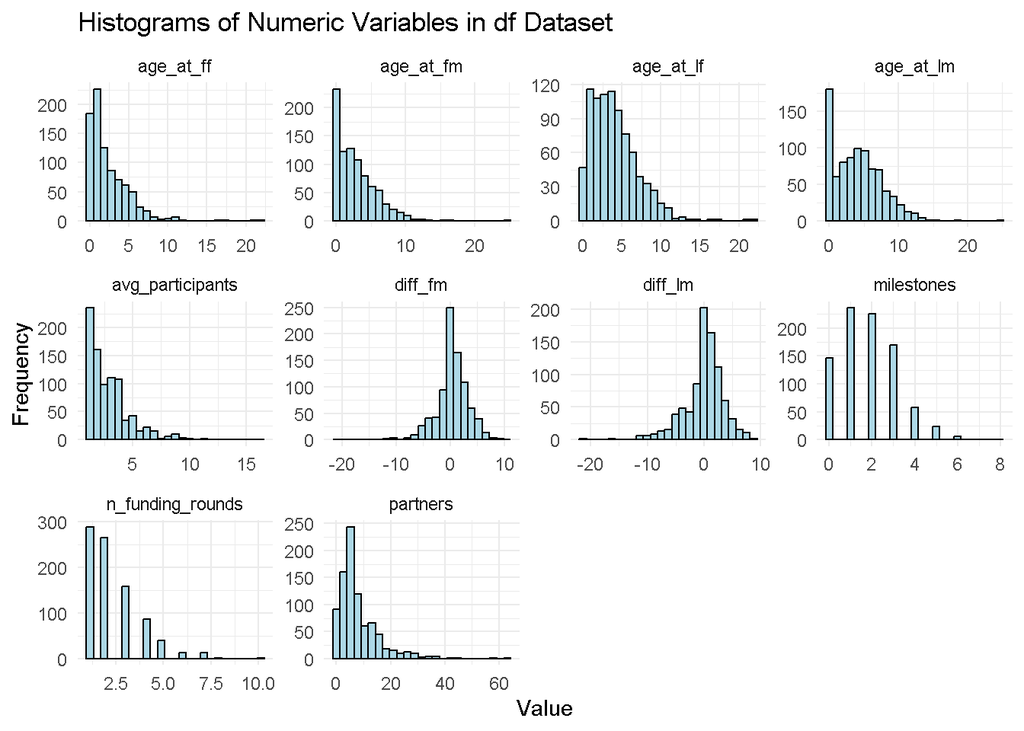

```r
library(MASS)
library(tidyverse)


df |>
  pivot_longer(cols = c("age_at_ff", "age_at_lf", "age_at_fm" ,"age_at_lm" , "avg_participants",
                        "milestones", "n_funding_rounds", "partners", "diff_fm","diff_lm"),
               names_to = "variable",
               values_to = "value") |>
  ggplot(aes(x = value)) +
  geom_histogram(bins = 25, color = "black", fill = "lightblue") +
  facet_wrap(~variable, scales = "free", ncol = 4) +
  labs(title = "Histograms of Numeric Variables in df Dataset",
       x = "Value",
       y = "Frequency") +
  theme_minimal()
```

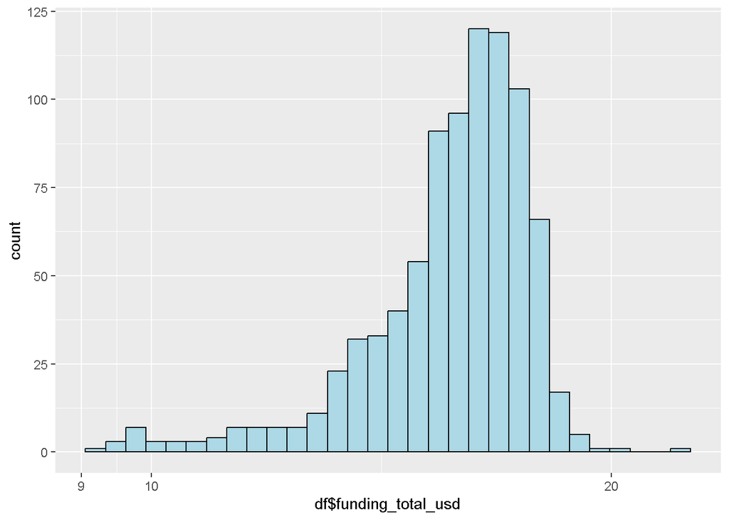

```r
df  |> ggplot(aes(x= df$funding_total_usd) )+ geom_histogram(bins = 30, color = "black", fill = "lightblue") + scale_x_log10()
```

2- Explore Categorical variables using bar charts

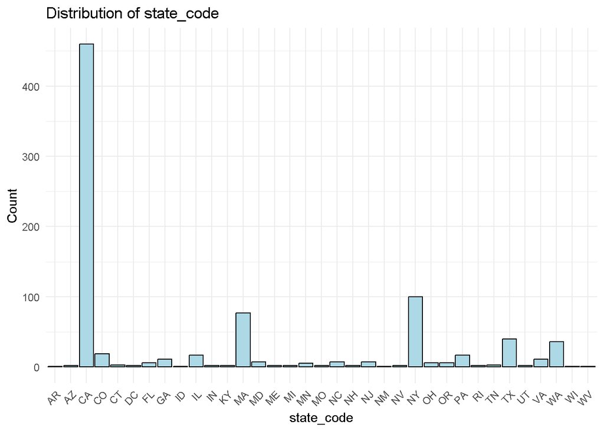

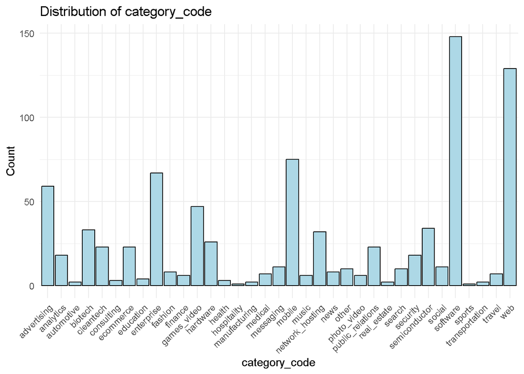

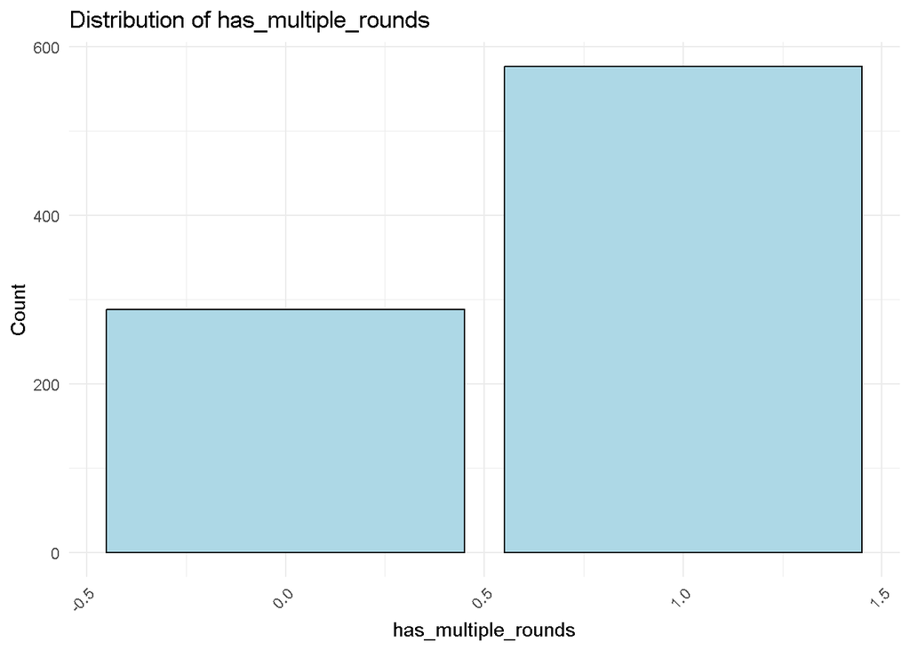

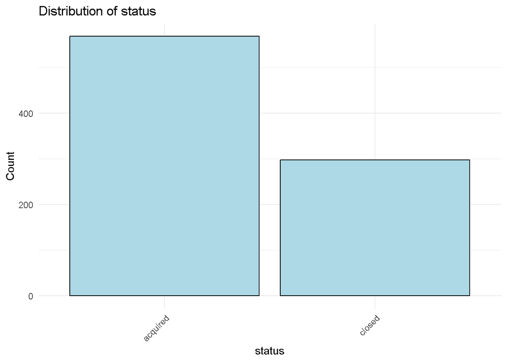

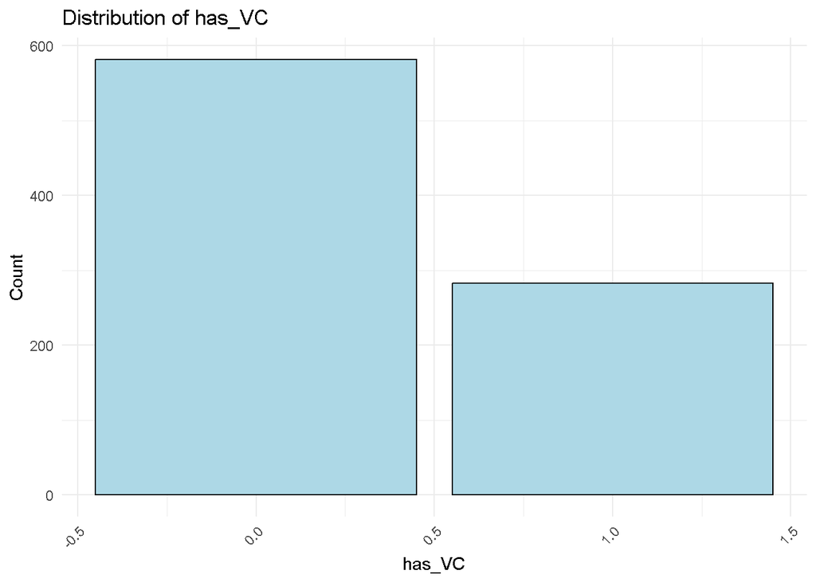

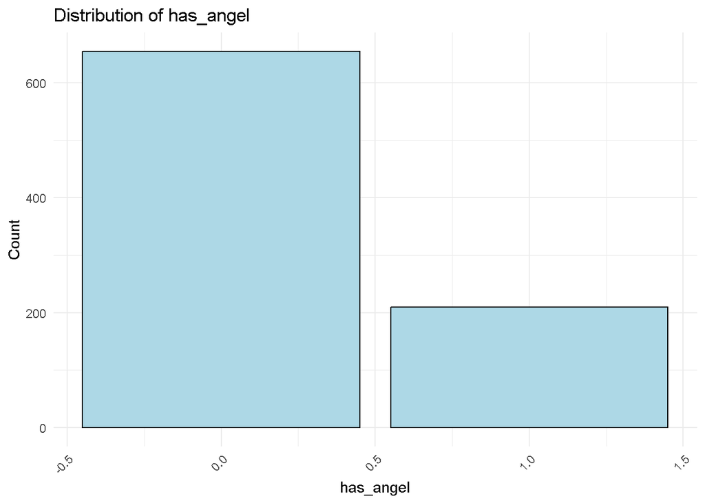

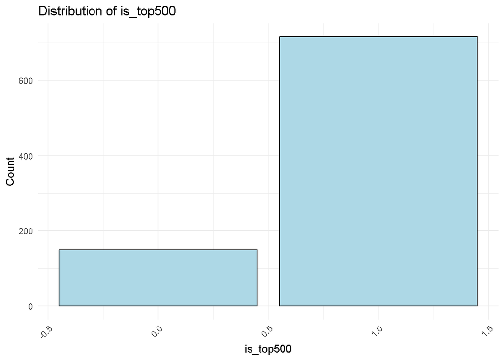

```r
library(ggplot2)
library(dplyr)

# Identifying categorical variables
categorical_vars <- df |> dplyr::select(c("state_code",  "category_code","has_multiple_rounds", "status","has_VC","has_angel","is_top500"))

# Plotting bar charts for each categorical variable
for (cat_var in names(categorical_vars)) {
  plot <- ggplot(df, aes_string(x = cat_var)) +
    geom_bar(fill = "lightblue", color = "black") +
    labs(title = paste("Distribution of", cat_var),
         x = cat_var,
         y = "Count") +
    theme_minimal() +
    theme(axis.text.x = element_text(angle = 45, hjust = 1))

   print(plot)
}
```

1)distribution of state_code CA (California): This state has the highest count by a significant margin, indicating that a large number of startups are based in California. Many other states have relatively lower counts, indicating fewer startups in those regions.

3)distribution of multiple rounds the startups in the dataset have gone through multiple rounds of funding, indicating ongoing investment and possibly growth.

4)status he acquired status has a higher count, indicating successful exits for many startups. The closed status has a lower count, indicating that fewer startups have shut down.

3- Correlation Matrix

```r
library(ggcorrplot)
# Selecting the variables of interest
variables_of_interest <- c("age_at_ff", "age_at_lf", "age_at_fm" ,"age_at_lm", "avg_participants",
                            "milestones", "n_funding_rounds", "partners", "funding_total_usd", "diff_fm","diff_lm","labels")

# Subsetting the dataframe with the selected variables
subset_df <- df[, variables_of_interest]

# Compute the correlation matrix
cor_matrix <- cor(subset_df, use = "complete.obs")

# Plot heat map
gg <- ggcorrplot(cor_matrix, method = "square", type = "lower",
                 lab = TRUE, lab_size = 3,
                 title = "Correlation Matrix of Selected Variables",
                 colors = c("#6E6E6E", "white", "lightblue"))  # Adjust colors as needed

# Customize plot appearance
gg <- gg + theme(axis.text.x = element_text(angle = 45, hjust = 1)) +
  coord_fixed(ratio = 0.5) + # Adjust the aspect ratio
  theme(legend.position = "bottom") + # Move legend to bottom
  theme(panel.grid.major = element_blank(), panel.grid.minor = element_blank()) + # Remove gridlines
  theme(axis.title.x = element_blank(), axis.title.y = element_blank()) + # Remove axis titles
  theme(legend.key.size = unit(0.5, "cm")) # Adjust legend key size
```

[output not shown]

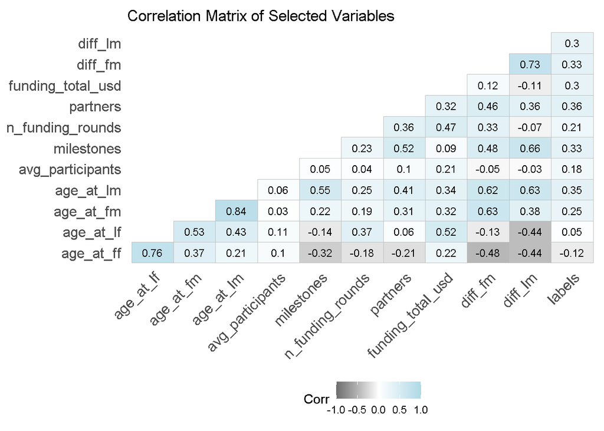

```r
# Display the plot
print(gg)
```

it seems that there a strong relationship between age_at_fm and age_at_lm with 0.84 correlation which might indicate a multicolinearity also between age_at_lf and age_at_ff with 0.76 correlation

4- Box Plot to study outliers

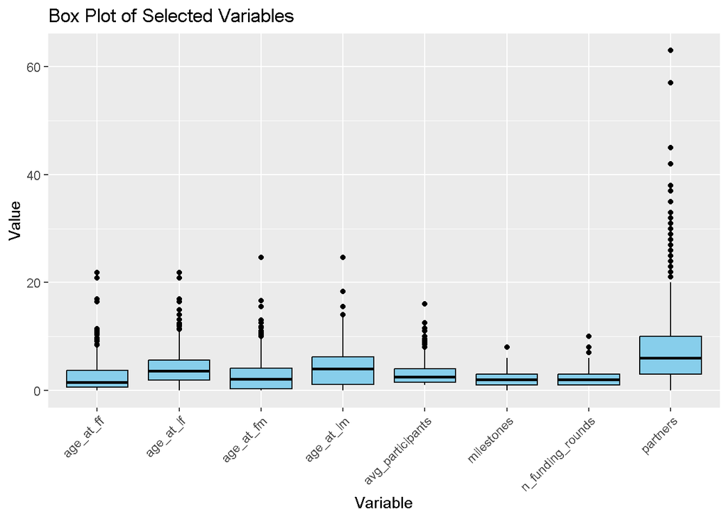

```r
library(ggplot2)

# Selecting the variables of interest
variables_of_interest <- c("age_at_ff", "age_at_lf", "age_at_fm" ,"age_at_lm", "avg_participants",
                            "milestones", "n_funding_rounds", "partners")

# Subsetting the dataframe with the selected variables
subset_df <- df[, variables_of_interest]

# Melt the data into long format for box plot
melted_df <- reshape2::melt(subset_df)
# Create the box plot
gg <- ggplot(melted_df, aes(x = variable, y = value)) +
  geom_boxplot(fill = "skyblue", color = "black", outlier.color = "black") +
  labs(title = "Box Plot of Selected Variables", x = "Variable", y = "Value") +
  theme(axis.text.x = element_text(angle = 45, hjust = 1),
        legend.position = "none") +  # Remove legend
  scale_y_continuous(labels = scales::comma)  # Add comma separator to y-axis labels if needed

# Adjust the size of the plot
options(repr.plot.width = 10, repr.plot.height = 8)  # Adjust width and height as needed

# Display the plot
print(gg)
```

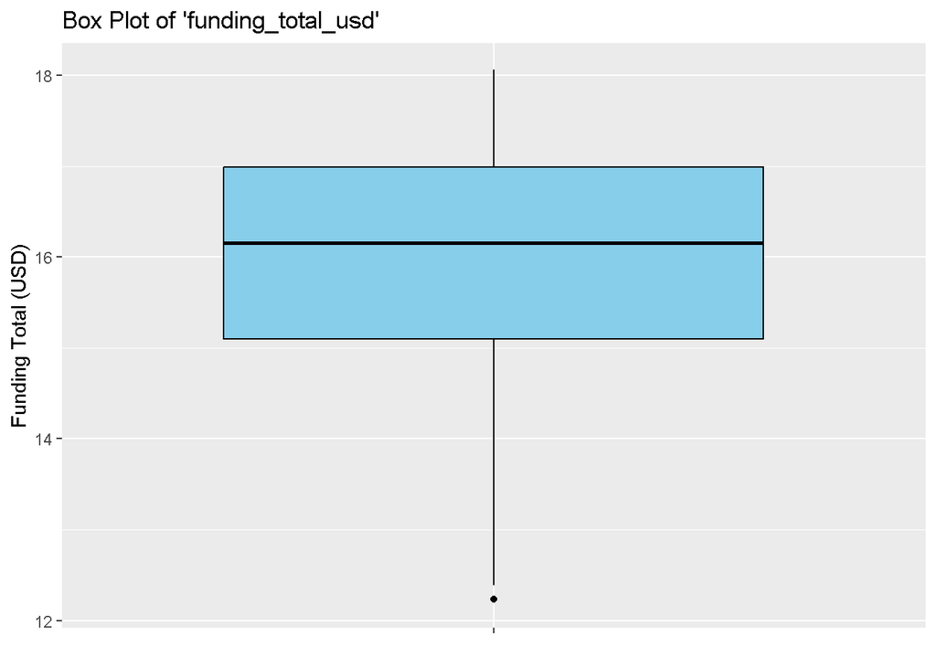

```r
library(ggplot2)

# Create the box plot
gg <- ggplot(df, aes(x = "", y = funding_total_usd)) +
  geom_boxplot(fill = "skyblue", color = "black", outlier.color = "black") +
  labs(title = "Box Plot of 'funding_total_usd'", x = "", y = "Funding Total (USD)") +
  theme(axis.text.x = element_blank(),  # Remove x-axis labels
        legend.position = "none") +     # Remove legend
  scale_y_continuous(labels = scales::comma, limits = quantile(df$funding_total_usd, c(0.05, 0.95)))  # Adjust y-axis limits

# Adjust the size of the plot
options(repr.plot.width = 8, repr.plot.height = 6)  # Adjust width and height as needed

# Display the plot
print(gg)
```

5- Start ups map

```r
# Load necessary library
library(leaflet)
library(leaflet.providers)
```

```r
# Define custom icons for the markers
customIcon <- makeIcon(
  iconUrl = "https://leafletjs.com/examples/custom-icons/leaf-green.png", # URL to a custom icon image
  iconWidth = 38, iconHeight = 38,
  iconAnchorX = 22, iconAnchorY = 34,
  shadowUrl = "https://leafletjs.com/examples/custom-icons/leaf-shadow.png", # URL to a custom shadow image
  shadowWidth = 50, shadowHeight = 64,
  shadowAnchorX = 4, shadowAnchorY = 62
)

# Create the leaflet map
map <- leaflet(df) %>%
  # Add GPS-like tile layer (e.g., from OpenStreetMap or another provider)
  addProviderTiles(providers$OpenStreetMap.Mapnik) %>%
  # Add markers with custom icons
  addMarkers(~longitude, ~latitude,
             icon = customIcon,
             popup = ~paste("<strong>Name:</strong>", name, "<br><strong>Status:</strong>", status),
             label = ~name) %>%
  # Set the initial view to the geographical center of the data
  setView(lng = mean(df$longitude, na.rm = TRUE),
          lat = mean(df$latitude, na.rm = TRUE),
          zoom = 10)

# Display the map
map
```

[interactive chart not shown]

6- Scatter Matrix

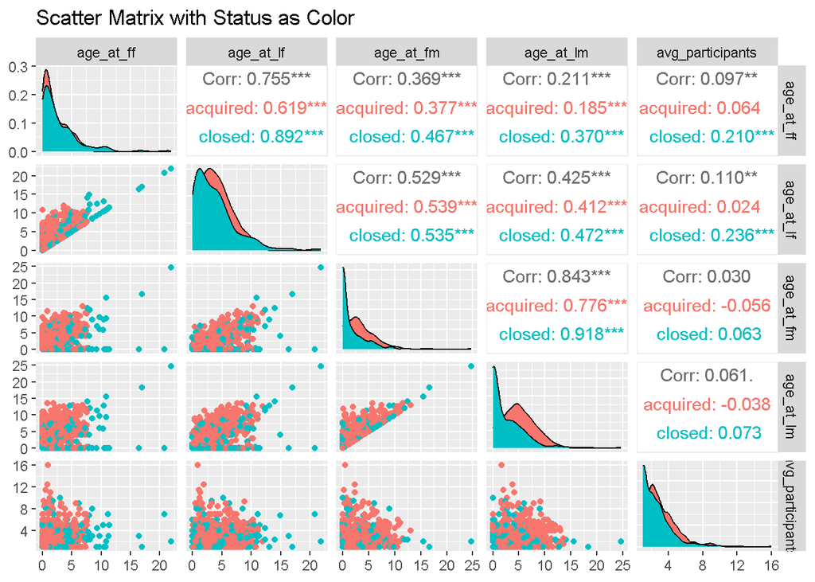

```r
library(GGally)

# Your variables of interest and including the target variable 'status'
variables_of_interest <- c("age_at_ff", "age_at_lf", "age_at_fm", "age_at_lm", "avg_participants",
                           "milestones", "n_funding_rounds", "partners", "funding_total_usd", "diff_fm", "diff_lm", "labels", "status")

# Subsetting the data frame with the selected variables
subset_df <- df[, variables_of_interest]

# Create a scatter matrix
ggpairs(subset_df, columns = 1:5, aes(color = status), title = "Scatter Matrix with Status as Color")
```

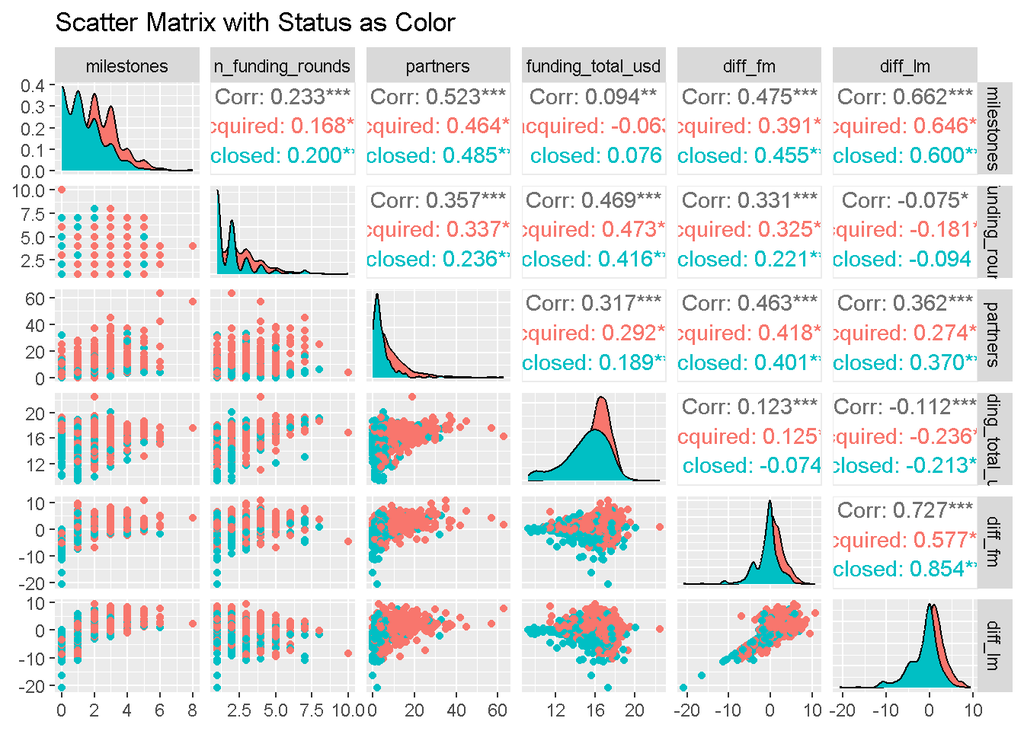

```r
library(GGally)

# Your variables of interest and including the target variable 'status'
variables_of_interest <- c("age_at_ff", "age_at_lf", "age_at_fm", "age_at_lm", "avg_participants",
                           "milestones", "n_funding_rounds", "partners", "funding_total_usd", "diff_fm", "diff_lm", "labels", "status")

# Subsetting the data frame with the selected variables
subset_df <- df[, variables_of_interest]

# Create a scatter matrix
ggpairs(subset_df, columns = 6:11, aes(color = status), title = "Scatter Matrix with Status as Color")
```

# **Initial feature selection and Standardization**

- Intial feature selection

```r
dt<-df_encoded|> dplyr::select(-c("name","city","labels","fundingRounds", "closed_at" ))
```

- divide data into coded and uncoded

```r
 dt_without_encoded <-  dt|> dplyr::select(-starts_with("is_"), -starts_with("state_code_"), -starts_with("category_code_") , -starts_with("has_"))
```

```r
dt_with_encoded <-  dt|> dplyr::select(starts_with("is_"), starts_with("state_code_"), starts_with("category_code_") , starts_with("has_"))
```

```r
str(dt_without_encoded)
```

```
## 'data.frame':    865 obs. of  17 variables:
##  $ latitude         : num  42.4 37.2 32.9 37.3 37.8 ...
##  $ longitude        : num  -71.1 -122 -117.2 -122.1 -122.4 ...
##  $ founded_at       : int  17 10 19 12 20 12 15 14 12 15 ...
##  $ first_funding_at : int  10 6 11 6 11 7 7 6 6 8 ...
##  $ last_funding_at  : int  8 7 8 5 10 4 8 8 11 8 ...
##  $ age_at_ff        : num  2.25 5.13 1.03 3.13 0 ...
##  $ age_at_lf        : num  3 10 1.03 5.32 1.67 ...
##  $ age_at_fm        : num  4.6685 7.0055 1.4575 6.0027 0.0384 ...
##  $ age_at_lm        : num  6.7041 7.0055 2.2055 6.0027 0.0384 ...
##  $ partners         : int  3 9 5 5 2 3 6 25 13 14 ...
##  $ n_funding_rounds : int  3 4 1 3 2 1 3 3 3 3 ...
##  $ funding_total_usd: num  12.8 17.5 14.8 17.5 14.1 ...
##  $ milestones       : int  3 1 2 1 1 1 2 3 4 4 ...
##  $ avg_participants : num  1 4.75 4 3.33 1 ...
##  $ status           : Factor w/ 2 levels "acquired","closed": 1 1 1 1 2 2 1 1 1 1 ...
##  $ diff_fm          : num  2.4192 1.8795 0.4246 2.8712 0.0384 ...
##  $ diff_lm          : num  3.701 -2.992 1.173 0.688 -1.63 ...
```

- Standardization

```r
numeric_cols <- dt_without_encoded |> dplyr::select(-status) |> names()
dt_without_encoded[numeric_cols] <- scale(dt_without_encoded[numeric_cols])
```

```r
dt_before_feature<- cbind(dt_without_encoded, dt_with_encoded)
```

# **features selection**

**Step1**: Filter-based Feature Selection **Step2**: Dimentionality reduction **Step3**: Embedded feature selection **Step4**: Desicion tree classifier

## Step1: Filter-based Feature Selection:

now, we will select the variable that is most correlated with the target variable (Status) by using

For numerical variables: - Bi-serial correlation -ANOVA

For categorical variables: - chi-square

### 1- Numerical variables:

#### - Bi-serial correlation

```r
library(ltm)
# Load the polycor package
library(polycor)

# Exclude 'state_code' and 'category_code' from the predictor variables
predictors <- df[, !names(df) %in% c("state_code", "category_code")]

# Convert 'status' to a numeric variable (0 for one level and 1 for the other)
numeric_status <- as.numeric(predictors$status) - 1  # Convert to 0-based index

# Remove the 'status' variable from the predictors
predictors <- predictors[, !names(predictors) %in% c("status")]

# Calculate Pearson correlation between each predictor variable and numeric_status
correlations <- sapply(predictors, function(x) cor(as.numeric(x), numeric_status))

# Display the correlation coefficients
#correlations


# Select variables with correlation magnitude above a certain threshold (e.g., 0.1)
selected_variables <- names(correlations[abs(correlations) > 0.1])

# Display selected variables
selected_variables
```

```
##  [1] NA                    NA                    "labels"
##  [4] NA                    "first_funding_at"    "age_at_ff"
##  [7] "age_at_fm"           "age_at_lm"           "partners"
## [10] "n_funding_rounds"    "funding_total_usd"   "milestones"
## [13] "is_otherstate"       "has_roundA"          "has_roundB"
## [16] "has_roundC"          "has_roundD"          "avg_participants"
## [19] "is_top500"           NA                    "diff_fm"
## [22] "diff_lm"             "has_multiple_rounds"
```

#### - ANOVA

```r
# Get the names of the numerical columns
numeric_columns <- sapply(dt_before_feature, is.numeric)

# Perform ANOVA for each numerical variable
anova_results <- lapply(names(dt_before_feature)[numeric_columns], function(var) {
  formula <- as.formula(paste(var, "~ status"))
  aov_result <- aov(formula, data = dt_before_feature)
  summary_aov <- summary(aov_result)
  p_value <- summary_aov[[1]][["Pr(>F)"]][1]
  return(p_value)
})

# Name the results for easier interpretation
names(anova_results) <- names(dt_before_feature)[numeric_columns]

significant_vars <- names(anova_results)[unlist(anova_results) < 0.05]
print(significant_vars)
```

```
##  [1] "latitude"                       "first_funding_at"
##  [3] "age_at_ff"                      "age_at_fm"
##  [5] "age_at_lm"                      "partners"
##  [7] "n_funding_rounds"               "funding_total_usd"
##  [9] "milestones"                     "avg_participants"
## [11] "diff_fm"                        "diff_lm"
## [13] "is_CA"                          "is_MA"
## [15] "is_otherstate"                  "is_enterprise"
## [17] "is_top500"                      "state_code_CA"
## [19] "state_code_CT"                  "state_code_MA"
## [21] "state_code_NC"                  "state_code_OH"
## [23] "state_code_PA"                  "category_code_cleantech"
## [25] "category_code_enterprise"       "category_code_hardware"
## [27] "category_code_other"            "category_code_public_relations"
## [29] "has_multiple_rounds"
```

### 2- Categorical variables

- chi-square

```r
categorical_variables <- c("state_code", "category_code")
target_variable<- "status"

significant_variables <- c()
# Create a contingency table for each categorical variable and the target variable
for (variable in categorical_variables) {
  contingency_table <- table(df[[variable]], df[[target_variable]])

  # Perform chi-square test
  chi_square_test <- chisq.test(contingency_table, simulate.p.value = TRUE)

  # Print the results
  cat("\nChi-square test for", variable, "vs.", target_variable, ":\n")
  print(chi_square_test)

  if (chi_square_test$p.value < 0.05) {
    significant_variables <- c(significant_variables, variable)
  }
}
```

```
##
## Chi-square test for state_code vs. status :
##
##  Pearson's Chi-squared test with simulated p-value (based on 2000
##  replicates)
##
## data:  contingency_table
## X-squared = 67.065, df = NA, p-value = 0.0004998
##
##
## Chi-square test for category_code vs. status :
##
##  Pearson's Chi-squared test with simulated p-value (based on 2000
##  replicates)
##
## data:  contingency_table
## X-squared = 58.637, df = NA, p-value = 0.001999
```

```r
# Print significant variables
print("Significant categorical variables:")
```

```
## [1] "Significant categorical variables:"
```

```r
print(significant_variables)
```

```
## [1] "state_code"    "category_code"
```

Therefore, both the “state_code” & “category_code” variables are significant for the prediction model.

### 3- Combine the selected numerical and Categorical features into a data frame

```r
f1<- dt_before_feature |> dplyr::select(c(
    "longitude" ,"latitude", "first_funding_at", "age_at_ff", "age_at_fm", "age_at_lm", "partners",
    "n_funding_rounds", "funding_total_usd", "milestones", "avg_participants", "diff_fm",
    "diff_lm", "is_CA", "is_MA", "is_otherstate", "is_enterprise", "is_top500", "state_code_CA",
    "state_code_CT", "state_code_MA", "state_code_NC", "state_code_OH", "state_code_PA",
    "category_code_cleantech", "category_code_enterprise", "category_code_hardware",
    "category_code_other", "category_code_public_relations", "has_roundA", "has_roundB",
    "has_roundC", "has_roundD", "has_multiple_rounds"
  ))
```

```r
f1_data<-cbind(f1, dt_before_feature$status)
f1_data <- f1_data |> rename( "status" = "dt_before_feature$status")
str(f1_data)
```

```
## 'data.frame':    865 obs. of  35 variables:
##  $ longitude                     : num  1.492 -0.835 -0.616 -0.838 -0.855 ...
##  $ latitude                      : num  1.077 -0.319 -1.501 -0.296 -0.171 ...
##  $ first_funding_at              : num  0.686 -1.074 1.127 -1.074 1.127 ...
##  $ age_at_ff                     : num  -0.0406 1.1127 -0.5282 0.3131 -0.9423 ...
##  $ age_at_fm                     : num  0.667 1.494 -0.471 1.139 -0.974 ...
##  $ age_at_lm                     : num  0.768 0.857 -0.563 0.561 -1.204 ...
##  $ partners                      : num  -0.658 0.152 -0.388 -0.388 -0.793 ...
##  $ n_funding_rounds              : num  0.466 1.176 -0.955 0.466 -0.245 ...
##  $ funding_total_usd             : num  -1.658 0.945 -0.579 0.944 -0.965 ...
##  $ milestones                    : num  0.871 -0.626 0.123 -0.626 -0.626 ...
##  $ avg_participants              : num  -0.999 0.992 0.594 0.24 -0.999 ...
##  $ diff_fm                       : num  0.66111 0.48115 -0.00395 0.81182 -0.13272 ...
##  $ diff_lm                       : num  1.079 -0.89 0.335 0.192 -0.49 ...
##  $ is_CA                         : int  1 1 1 1 1 1 1 1 0 1 ...
```

[output cut: 21 more lines]

### 4- Validation

Cross_validation

```r
# Load necessary libraries
library(caret)
# Set the seed for reproducibility
set.seed(123)

# Split the data into training and test sets
trainIndex <- createDataPartition(f1_data$status, p = .8,
                                  list = FALSE,
                                  times = 1)
data_train <- f1_data[trainIndex, ]
data_test <- f1_data[-trainIndex, ]

# Define your training control for k-fold cross-validation
ctrl <- trainControl(method = "cv",   # Cross-validation method
                     number = 5)      # Number of folds

# Define your model. Let's assume you're using logistic regression
model <- train(status ~ .,
               data = data_train,          # training data
               method = "glm",            # Logistic regression
               trControl = ctrl, family = binomial())          # Training control

# Print the results
summary(model)
```

```
##
## Call:
## NULL
##
## Coefficients: (3 not defined because of singularities)
##                                  Estimate Std. Error z value Pr(>|z|)
## (Intercept)                      -0.56705    0.48149  -1.178  0.23892
## longitude                         0.15899    0.21110   0.753  0.45136
## latitude                         -0.21644    0.12489  -1.733  0.08308 .
## first_funding_at                 -0.13146    0.14532  -0.905  0.36566
## age_at_ff                         0.02259    0.31070   0.073  0.94203
## age_at_fm                        -0.19848    0.26509  -0.749  0.45401
## age_at_lm                         0.05041    0.50110   0.101  0.91987
## partners                         -1.23643    0.24411  -5.065 4.08e-07 ***
## n_funding_rounds                  0.18319    0.19533   0.938  0.34832
## funding_total_usd                -0.51281    0.17039  -3.010  0.00262 **
## milestones                       -0.01292    0.20558  -0.063  0.94989
## avg_participants                 -0.22990    0.12248  -1.877  0.06051 .
## diff_fm                                NA         NA      NA       NA
## diff_lm                          -0.49385    0.41102  -1.202  0.22954
## is_CA                           -19.90442 2399.54472  -0.008  0.99338
## is_MA                            -0.60188    0.50501  -1.192  0.23334
## is_otherstate                     0.17686    0.39842   0.444  0.65711
## is_enterprise                     0.23699    0.41748   0.568  0.57027
## is_top500                        -0.71530    0.28024  -2.552  0.01070 *
## state_code_CA                    20.25435 2399.54476   0.008  0.99327
## state_code_CT                    15.72320 1678.42329   0.009  0.99253
## state_code_MA                          NA         NA      NA       NA
## state_code_NC                     2.54663    1.26975   2.006  0.04490 *
## state_code_OH                    15.13448  819.01282   0.018  0.98526
## state_code_PA                     0.70318    0.79179   0.888  0.37449
## category_code_cleantech           0.94151    0.57774   1.630  0.10318
## category_code_enterprise               NA         NA      NA       NA
## category_code_hardware            1.64467    0.63548   2.588  0.00965 **
## category_code_other               4.05399    1.37969   2.938  0.00330 **
## category_code_public_relations    1.36931    0.71915   1.904  0.05690 .
## has_roundATRUE                    0.19389    0.24738   0.784  0.43318
## has_roundBTRUE                   -0.25675    0.27486  -0.934  0.35024
## has_roundCTRUE                   -0.26113    0.33888  -0.771  0.44096
## has_roundDTRUE                   -0.98176    0.54071  -1.816  0.06942 .
## has_multiple_rounds              -0.35392    0.31639  -1.119  0.26330
## ---
## Signif. codes:  0 '***' 0.001 '**' 0.01 '*' 0.05 '.' 0.1 ' ' 1
##
## (Dispersion parameter for binomial family taken to be 1)
##
##     Null deviance: 891.60  on 692  degrees of freedom
## Residual deviance: 589.82  on 661  degrees of freedom
## AIC: 653.82
##
## Number of Fisher Scoring iterations: 15
```

```r
print(model)
```

```
## Generalized Linear Model
##
## 693 samples
##  34 predictor
##   2 classes: 'acquired', 'closed'
##
## No pre-processing
## Resampling: Cross-Validated (5 fold)
## Summary of sample sizes: 554, 555, 555, 554, 554
## Resampling results:
##
##   Accuracy   Kappa
##   0.7979668  0.5323619
```

## Step2: Dimentionality reduction

### - PCA

```r
library(biotools)
```

#### 1- Selecting numerical variables

```r
f1_data_without_status <- f1_data |> dplyr::select (-status)
```

#### 2- Perform PCA

```r
pca_result <- prcomp(f1_data_without_status, center = TRUE, scale. = FALSE)
```

```r
# Standard deviations of the principal components
pca_result$sdev
```

```
##  [1] 2.036796e+00 1.498422e+00 1.320705e+00 1.254257e+00 1.032662e+00
##  [6] 8.690325e-01 8.233768e-01 7.812263e-01 7.022870e-01 6.233971e-01
## [11] 4.852423e-01 4.495750e-01 4.012148e-01 3.709858e-01 3.651122e-01
## [16] 3.395554e-01 3.239558e-01 3.102366e-01 2.926449e-01 2.538688e-01
## [21] 2.156869e-01 1.776517e-01 1.676809e-01 1.537919e-01 1.511045e-01
## [26] 1.285227e-01 1.060681e-01 8.477913e-02 7.814452e-02 5.761079e-02
## [31] 2.387455e-02 9.045192e-16 1.457882e-16 1.383627e-16
```

```r
# Proportion of variance explained by each principal component
prop_var <- pca_result$sdev^2 / sum(pca_result$sdev^2)

# Cumulative proportion of variance explained
cum_var <- cumsum(prop_var)

# Print cumulative proportion of variance explained
print(cum_var)
```

```
##  [1] 0.2722739 0.4196337 0.5341118 0.6373603 0.7073490 0.7569149 0.8014096
##  [8] 0.8414653 0.8738351 0.8993410 0.9147945 0.9280598 0.9386247 0.9476575
## [15] 0.9564066 0.9639738 0.9708616 0.9771784 0.9827991 0.9870290 0.9900823
## [22] 0.9921536 0.9939989 0.9955512 0.9970498 0.9981339 0.9988723 0.9993440
## [29] 0.9997448 0.9999626 1.0000000 1.0000000 1.0000000 1.0000000
```

```r
# Print rotation matrix (loadings)
pca_result$rotation
```

```
##                                         PC1           PC2           PC3
## longitude                      -0.063033449  0.0761664788 -0.6542252309
## latitude                       -0.009331747  0.0634826930 -0.5358315508
## first_funding_at               -0.205954956  0.3692733619  0.0703437505
## age_at_ff                      -0.094959476 -0.4762313821 -0.0347273204
## age_at_fm                       0.349610534 -0.1935805263 -0.0665604902
## age_at_lm                       0.419246098 -0.0924331827 -0.0388993307
## partners                        0.331480782  0.0368152626  0.0312860089
## n_funding_rounds                0.236522566 -0.1966813823 -0.1312551260
## funding_total_usd               0.219721506 -0.4540934685 -0.0197349168
## milestones                      0.333615595  0.2644695353  0.0068303782
## avg_participants                0.038614370 -0.1681128977  0.0668942643
## diff_fm                         0.408048098  0.2138614474 -0.0337685168
## diff_lm                         0.336316324  0.3925912820  0.0603976290
## is_CA                           0.032243290 -0.0385325754  0.3152589720
## is_MA                           0.008152213 -0.0095811112 -0.1091412905
## is_otherstate                  -0.035718353  0.0110957801 -0.1323282089
## is_enterprise                   0.011732867  0.0059383724  0.0003105314
## is_top500                       0.053230480 -0.0623221582  0.0063876955
## state_code_CA                   0.032858838 -0.0383048063  0.3157509052
## state_code_CT                  -0.001212430  0.0006905315 -0.0034481350
## state_code_MA                   0.008152213 -0.0095811112 -0.1091412905
## state_code_NC                   0.001238895 -0.0070890318 -0.0050240020
## state_code_OH                  -0.004614430  0.0043449517 -0.0039810090
## state_code_PA                  -0.007109175  0.0057778070 -0.0161852191
## category_code_cleantech        -0.004467832 -0.0075059699  0.0080755320
## category_code_enterprise        0.011732867  0.0059383724  0.0003105314
## category_code_hardware         -0.001204128 -0.0159965115  0.0088780623
## category_code_other            -0.001472543 -0.0052565721 -0.0007289587
## category_code_public_relations -0.007486563 -0.0093643015 -0.0005118708
## has_roundA                      0.090734746  0.0514446948  0.0203291815
## has_roundB                      0.099209182 -0.0896066921 -0.0116865833
## has_roundC                      0.063952318 -0.1073709341 -0.0098618327
## has_roundD                      0.036432724 -0.0677347731 -0.0052491962
## has_multiple_rounds             0.098610305 -0.0463179170 -0.0572159197
##                                          PC4           PC5           PC6
## longitude                       0.0004977456 -0.0586739107  0.2893103331
## latitude                        0.0123379882 -0.1294027051 -0.4957278594
## first_funding_at                0.0563671237 -0.2738844934  0.4264193789
## age_at_ff                       0.4615204439 -0.0945272070  0.2939705918
```

[output cut: 365 more lines]

```
## state_code_CT                  -3.575898e-15
## state_code_MA                   6.743551e-01
## state_code_NC                  -4.423954e-15
## state_code_OH                  -3.461332e-15
## state_code_PA                   1.552344e-15
## category_code_cleantech         1.172396e-16
## category_code_enterprise        2.115427e-01
## category_code_hardware         -7.520814e-16
## category_code_other             1.152583e-15
## category_code_public_relations  1.946816e-16
## has_roundA                      1.128486e-16
## has_roundB                      4.959145e-16
## has_roundC                     -8.367830e-16
## has_roundD                     -4.479260e-16
## has_multiple_rounds             2.055492e-16
```

```r
# Print scores (transformed data)
pca_scores <- pca_result$xs
```

#### 3- Visulaizing

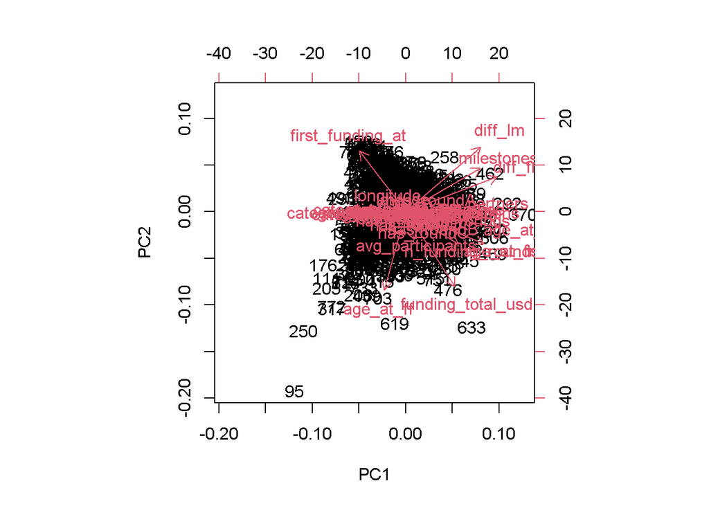

```r
# Biplot
biplot(pca_result)
```

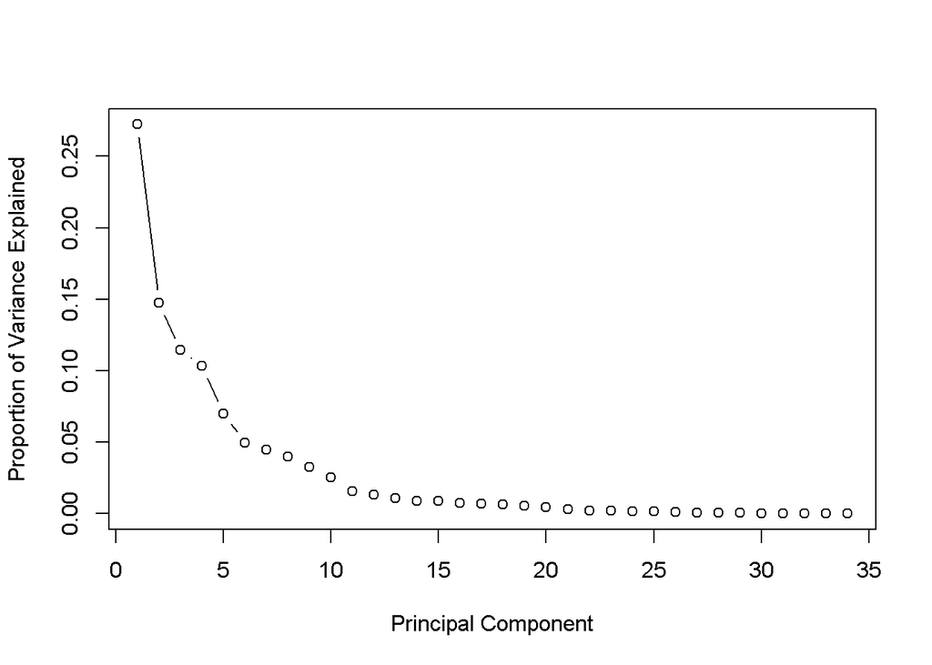

```r
# Scree plot
plot(prop_var, type = "b", xlab = "Principal Component", ylab = "Proportion of Variance Explained")
```

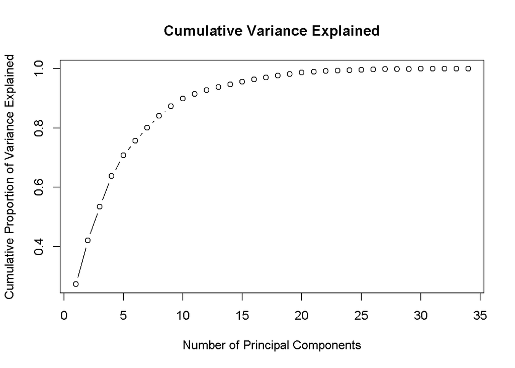

```r
# Cumulative proportion of variance explained
cum_var <- cumsum(prop_var)

# Plot cumulative proportion of variance explained
plot(cum_var, type = "b", xlab = "Number of Principal Components", ylab = "Cumulative Proportion of Variance Explained", main = "Cumulative Variance Explained")
```

#### 4- Validation

Choosing the PCAs with the most explained variation

```r
# Eigenvalues
eigenvalues <- pca_result$sdev^2

# Components with eigenvalues > 1
num_components_kaiser <- sum(eigenvalues > 1)
num_components_kaiser
```

```
## [1] 5
```

The Kaiser Criterion suggests keeping 5 components with eigenvalues (variance explained) greater than 1

#### 5- Extract the scores of the first 5 principal components

```r
pca_scores <- as.data.frame(pca_result$x[, 1:5])
```

```r
loadings <- pca_result$rotation[, 1:5]

# loadings now contains the contributions of each original feature to the first 5 principal components
print(loadings)
```

```
##                                         PC1           PC2           PC3
## longitude                      -0.063033449  0.0761664788 -0.6542252309
## latitude                       -0.009331747  0.0634826930 -0.5358315508
## first_funding_at               -0.205954956  0.3692733619  0.0703437505
## age_at_ff                      -0.094959476 -0.4762313821 -0.0347273204
## age_at_fm                       0.349610534 -0.1935805263 -0.0665604902
## age_at_lm                       0.419246098 -0.0924331827 -0.0388993307
## partners                        0.331480782  0.0368152626  0.0312860089
## n_funding_rounds                0.236522566 -0.1966813823 -0.1312551260
## funding_total_usd               0.219721506 -0.4540934685 -0.0197349168
## milestones                      0.333615595  0.2644695353  0.0068303782
## avg_participants                0.038614370 -0.1681128977  0.0668942643
## diff_fm                         0.408048098  0.2138614474 -0.0337685168
## diff_lm                         0.336316324  0.3925912820  0.0603976290
## is_CA                           0.032243290 -0.0385325754  0.3152589720
## is_MA                           0.008152213 -0.0095811112 -0.1091412905
## is_otherstate                  -0.035718353  0.0110957801 -0.1323282089
## is_enterprise                   0.011732867  0.0059383724  0.0003105314
## is_top500                       0.053230480 -0.0623221582  0.0063876955
## state_code_CA                   0.032858838 -0.0383048063  0.3157509052
## state_code_CT                  -0.001212430  0.0006905315 -0.0034481350
## state_code_MA                   0.008152213 -0.0095811112 -0.1091412905
## state_code_NC                   0.001238895 -0.0070890318 -0.0050240020
## state_code_OH                  -0.004614430  0.0043449517 -0.0039810090
## state_code_PA                  -0.007109175  0.0057778070 -0.0161852191
## category_code_cleantech        -0.004467832 -0.0075059699  0.0080755320
## category_code_enterprise        0.011732867  0.0059383724  0.0003105314
## category_code_hardware         -0.001204128 -0.0159965115  0.0088780623
## category_code_other            -0.001472543 -0.0052565721 -0.0007289587
## category_code_public_relations -0.007486563 -0.0093643015 -0.0005118708
## has_roundA                      0.090734746  0.0514446948  0.0203291815
## has_roundB                      0.099209182 -0.0896066921 -0.0116865833
## has_roundC                      0.063952318 -0.1073709341 -0.0098618327
## has_roundD                      0.036432724 -0.0677347731 -0.0052491962
## has_multiple_rounds             0.098610305 -0.0463179170 -0.0572159197
##                                          PC4           PC5
## longitude                       0.0004977456 -0.0586739107
## latitude                        0.0123379882 -0.1294027051
## first_funding_at                0.0563671237 -0.2738844934
## age_at_ff                       0.4615204439 -0.0945272070
```

[output cut: 15 more lines]

```
## state_code_CT                  -0.0005806945  0.0007980845
## state_code_MA                  -0.0045783259 -0.0045041063
## state_code_NC                   0.0041583966 -0.0024011119
## state_code_OH                   0.0015796746  0.0005129075
## state_code_PA                  -0.0002206508  0.0062099314
## category_code_cleantech        -0.0050605581 -0.0031434115
## category_code_enterprise       -0.0114079397 -0.0001098136
## category_code_hardware          0.0088158684  0.0026421271
## category_code_other             0.0021439609  0.0036499471
## category_code_public_relations  0.0119119998 -0.0016603923
## has_roundA                     -0.1243564688  0.0467186351
## has_roundB                     -0.1386949051  0.0635886574
## has_roundC                     -0.1043261900  0.0018425993
## has_roundD                     -0.0274148466 -0.0189818790
## has_multiple_rounds            -0.1856122891  0.0649147408
```

#### 6- Create pca_data to contain the selected PCAs

```r
# Convert f1_data to a numeric matrix
f1_data_matrix <- as.matrix(f1_data_without_status)

# Perform matrix multiplication with loadings
pca_data <- f1_data_matrix %*% loadings

# Now pca_data contains the transformed data using principal components
```

```r
f2_data<- as.data.frame(cbind(pca_data, f1_data$status))
f2_data <- f2_data |> rename( "status" = "V6")
```

```r
str(f2_data)
```

```
## 'data.frame':    865 obs. of  6 variables:
##  $ PC1   : num  0.889 1.756 -0.628 1.682 -1.714 ...
##  $ PC2   : num  1.73 -3.05 1.08 -1.84 1.14 ...
##  $ PC3   : num  -1.071 0.848 2.202 0.981 1.385 ...
##  $ PC4   : num  0.91 -0.252 -0.122 -0.103 -0.992 ...
##  $ PC5   : num  0.7249 -0.0216 -0.6592 0.6506 0.9625 ...
##  $ status: num  1 1 1 1 2 2 1 1 1 1 ...
```

## Step3: Embeded Feature selection: LASSO

### - LASSO

#### 1- Perform the Model

- **Select variables**

```r
str(f1_data)
```

```
## 'data.frame':    865 obs. of  35 variables:
##  $ longitude                     : num  1.492 -0.835 -0.616 -0.838 -0.855 ...
##  $ latitude                      : num  1.077 -0.319 -1.501 -0.296 -0.171 ...
##  $ first_funding_at              : num  0.686 -1.074 1.127 -1.074 1.127 ...
##  $ age_at_ff                     : num  -0.0406 1.1127 -0.5282 0.3131 -0.9423 ...
##  $ age_at_fm                     : num  0.667 1.494 -0.471 1.139 -0.974 ...
##  $ age_at_lm                     : num  0.768 0.857 -0.563 0.561 -1.204 ...
##  $ partners                      : num  -0.658 0.152 -0.388 -0.388 -0.793 ...
##  $ n_funding_rounds              : num  0.466 1.176 -0.955 0.466 -0.245 ...
##  $ funding_total_usd             : num  -1.658 0.945 -0.579 0.944 -0.965 ...
##  $ milestones                    : num  0.871 -0.626 0.123 -0.626 -0.626 ...
##  $ avg_participants              : num  -0.999 0.992 0.594 0.24 -0.999 ...
##  $ diff_fm                       : num  0.66111 0.48115 -0.00395 0.81182 -0.13272 ...
##  $ diff_lm                       : num  1.079 -0.89 0.335 0.192 -0.49 ...
##  $ is_CA                         : int  1 1 1 1 1 1 1 1 0 1 ...
```

[output cut: 21 more lines]

```r
# Select categorical variables
categorical_vars <- c("state_code", "category_code")

# Encode categorical variables
encoded_categorical <- model.matrix(~ . - 1, data = f2_data)

# Combine PCA-transformed data with encoded categorical variables
x1 <- cbind(pca_data, encoded_categorical)

# Define response variable
y1 <- as.factor(factor(f1_data$status, levels = c("closed", "acquired"), labels = c(0, 1)))
```

```r
str(as.data.frame(cbind(x1,y1)))
```

```
## 'data.frame':    865 obs. of  12 variables:
##  $ PC1   : num  0.889 1.756 -0.628 1.682 -1.714 ...
##  $ PC2   : num  1.73 -3.05 1.08 -1.84 1.14 ...
##  $ PC3   : num  -1.071 0.848 2.202 0.981 1.385 ...
##  $ PC4   : num  0.91 -0.252 -0.122 -0.103 -0.992 ...
##  $ PC5   : num  0.7249 -0.0216 -0.6592 0.6506 0.9625 ...
##  $ PC1   : num  0.889 1.756 -0.628 1.682 -1.714 ...
##  $ PC2   : num  1.73 -3.05 1.08 -1.84 1.14 ...
##  $ PC3   : num  -1.071 0.848 2.202 0.981 1.385 ...
##  $ PC4   : num  0.91 -0.252 -0.122 -0.103 -0.992 ...
##  $ PC5   : num  0.7249 -0.0216 -0.6592 0.6506 0.9625 ...
##  $ status: num  1 1 1 1 2 2 1 1 1 1 ...
##  $ y1    : num  2 2 2 2 1 1 2 2 2 2 ...
```

```r
# Convert the status variable to 0 and 1
f2_data <- f1_data %>%
  mutate(status = ifelse(status == "acquired", 1, 0))

# Combine the factors with pca_data
f2_data <- as.data.frame(cbind(pca_data, state_code = f1_data$state_code,
                       category_code = f1_data$category_code,
                       status = f1_data$status))



# Check the structure of the combined dataframe
str(f2_data)
```

```
## 'data.frame':    865 obs. of  6 variables:
##  $ PC1   : num  0.889 1.756 -0.628 1.682 -1.714 ...
##  $ PC2   : num  1.73 -3.05 1.08 -1.84 1.14 ...
##  $ PC3   : num  -1.071 0.848 2.202 0.981 1.385 ...
##  $ PC4   : num  0.91 -0.252 -0.122 -0.103 -0.992 ...
##  $ PC5   : num  0.7249 -0.0216 -0.6592 0.6506 0.9625 ...
##  $ status: num  1 1 1 1 2 2 1 1 1 1 ...
```

- **Model**

```r
# Set seed for reproducibility
set.seed(123)

# Divide the data into training and testing sets
train_indices <- sample(1:nrow(f2_data), 0.8 * nrow(f2_data))  # 80% for training
train_data <- f2_data[train_indices, ]
test_data <- f2_data[-train_indices, ]

# Prepare predictors (X) and response (y) for training and testing sets
X_train <- as.matrix(train_data[, -which(names(train_data) %in% c("status"))])  # Exclude status column
y_train <- train_data$status - 1  # Convert status to 0s and 1s

X_test <- as.matrix(test_data[, -which(names(test_data) %in% c("status"))])  # Exclude status column
y_test <- test_data$status - 1  # Convert status to 0s and 1s

# Perform LASSO regression with cross-validation
lasso_model <- cv.glmnet(X_train, y_train, family = "binomial", alpha = 1)

# Print the optimal lambda value selected by cross-validation
print(lasso_model$lambda.min)
```

```
## [1] 0.004353752
```

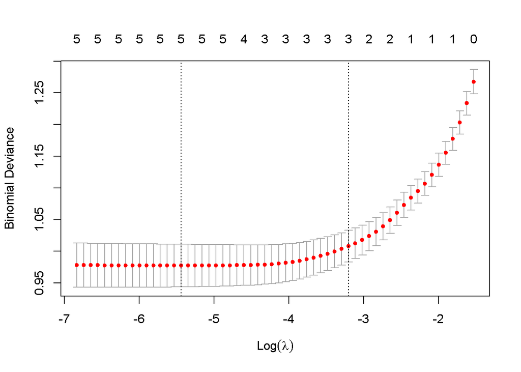

```r
# Plot the cross-validation curve
plot(lasso_model)
```

#### 2- **features extraction**

```r
# Extract coefficients
coefficients <- as.matrix(coef(lasso_model, s = "lambda.min"))

# Check the values of coefficients != 0
non_zero_indices <- which(coefficients != 0)

# Extract variable names based on non-zero indices
non_zero_variables <- rownames(coefficients)[non_zero_indices]
non_zero_variables
```

```
## [1] "(Intercept)" "PC1"         "PC2"         "PC3"         "PC4"
## [6] "PC5"
```

#### 3- Model validation

```r
# Predict probabilities for the test set
pred_prob <- predict(lasso_model, newx = X_test, s = "lambda.min", type = "response")

# Convert probabilities to class predictions (0 or 1)
pred_class <- ifelse(pred_prob > 0.5, 1, 0)

# Compute accuracy
accuracy <- sum(pred_class == y_test) / length(y_test)
cat("Accuracy:", accuracy, "\n")
```

```
## Accuracy: 0.7109827
```

```r
# Compute precision
precision <- sum(pred_class == 1 & y_test == 1) / sum(pred_class == 1)
cat("Precision:", precision, "\n")
```

```
## Precision: 0.6938776
```

```r
# Compute recall
recall <- sum(pred_class == 1 & y_test == 1) / sum(y_test == 1)
cat("Recall:", recall, "\n")
```

```
## Recall: 0.4927536
```

```r
# Compute F1-score
f1_score <- 2 * (precision * recall) / (precision + recall)
cat("F1-score:", f1_score, "\n")
```

```
## F1-score: 0.5762712
```

```r
# Compute AUC
library(pROC)
roc_obj <- roc(y_test, pred_prob)
auc <- auc(roc_obj)
cat("AUC:", auc, "\n")
```

```
## AUC: 0.7469342
```

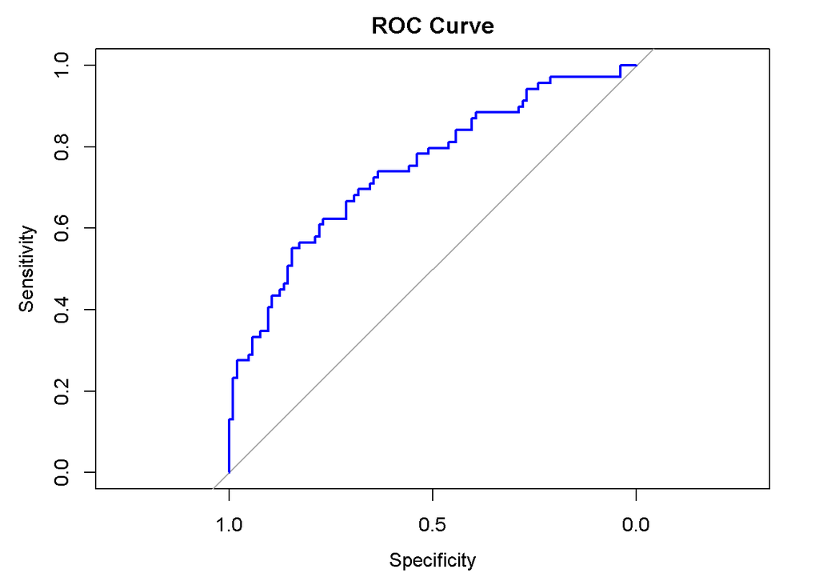

```r
# Plot ROC curve
plot(roc_obj, main = "ROC Curve", col = "blue", lwd = 2)
```

## Step4: Desicion tree classifier

```r
library(rpart)
# Splitting data into training and testing sets
set.seed(123) # for reproducibility
train_index <- sample(1:nrow(f1_data), 0.7*nrow(f1_data))
train_data <- f1_data[train_index, ]
test_data <- f1_data[-train_index, ]

# Building the decision tree model
tree_model <- rpart(status ~ ., data = train_data, method = "class")

# Print summary of the tree
summary(tree_model)
```

```
## Call:
## rpart(formula = status ~ ., data = train_data, method = "class")
##   n= 605
##
##           CP nsplit rel error    xerror       xstd
## 1 0.33333333      0 1.0000000 1.0000000 0.05828904
## 2 0.04292929      1 0.6666667 0.7272727 0.05290404
## 3 0.03030303      3 0.5808081 0.6464646 0.05073659
## 4 0.02525253      5 0.5202020 0.6565657 0.05102413
## 5 0.02020202      7 0.4696970 0.6515152 0.05088098
## 6 0.01000000      8 0.4494949 0.6363636 0.05044407
##
## Variable importance
##          partners         age_at_lm           diff_lm funding_total_usd
##                25                11                11                10
##         age_at_fm           diff_fm        milestones  avg_participants
##                 9                 8                 7                 5
##          latitude         age_at_ff  n_funding_rounds        has_roundB
##                 4                 2                 2                 2
##  first_funding_at        has_roundD         longitude             is_MA
##                 1                 1                 1                 1
##     state_code_MA
##                 1
##
## Node number 1: 605 observations,    complexity param=0.3333333
##   predicted class=acquired  expected loss=0.3272727  P(node) =1
##     class counts:   407   198
##    probabilities: 0.673 0.327
##   left son=2 (431 obs) right son=3 (174 obs)
##   Primary splits:
##       partners  < -0.5906763  to the right, improve=64.14926, (0 missing)
##       age_at_lm < -0.7966683  to the right, improve=61.36393, (0 missing)
##       age_at_fm < -0.8299954  to the right, improve=47.86400, (0 missing)
##       diff_fm   < 0.007937298 to the right, improve=35.56038, (0 missing)
##       diff_lm   < 0.0392557   to the right, improve=31.92118, (0 missing)
##   Surrogate splits:
##       age_at_lm  < -0.9664744  to the right, agree=0.800, adj=0.305, (0 split)
##       age_at_fm  < -0.8988946  to the right, agree=0.792, adj=0.276, (0 split)
##       diff_lm    < -0.6563222  to the right, agree=0.770, adj=0.201, (0 split)
##       diff_fm    < -0.3460464  to the right, agree=0.765, adj=0.184, (0 split)
```

[output cut: 149 more lines]

```
##
## Node number 49: 8 observations
##   predicted class=closed    expected loss=0.25  P(node) =0.01322314
##     class counts:     2     6
##    probabilities: 0.250 0.750
##
## Node number 50: 9 observations
##   predicted class=acquired  expected loss=0.2222222  P(node) =0.01487603
##     class counts:     7     2
##    probabilities: 0.778 0.222
##
## Node number 51: 12 observations
##   predicted class=closed    expected loss=0.08333333  P(node) =0.01983471
##     class counts:     1    11
##    probabilities: 0.083 0.917
```

```r
# Extracting selected features
selected_features <- colnames(train_data)[which(names(tree_model$frame) != "yval")]

# Print selected features
print(selected_features)
```

```
## [1] "longitude"         "latitude"          "first_funding_at"
## [4] "age_at_ff"         "age_at_lm"         "partners"
## [7] "n_funding_rounds"  "funding_total_usd"
```

```r
# Making predictions on the test data
predictions <- predict(tree_model, test_data, type = "class")

# Evaluating the model
confusion_matrix <- table(predictions, test_data$status)
accuracy <- sum(diag(confusion_matrix)) / sum(confusion_matrix)
print(confusion_matrix)
```

```
##
## predictions acquired closed
##    acquired      141     54
##    closed         20     45
```

```r
cat("Accuracy:", accuracy)
```

```
## Accuracy: 0.7153846
```

```r
library(rpart.plot)
printcp(tree_model)
```

```
##
## Classification tree:
## rpart(formula = status ~ ., data = train_data, method = "class")
##
## Variables actually used in tree construction:
## [1] age_at_lm         avg_participants  funding_total_usd latitude
## [5] partners
##
## Root node error: 198/605 = 0.32727
##
## n= 605
##
##         CP nsplit rel error  xerror     xstd
## 1 0.333333      0   1.00000 1.00000 0.058289
## 2 0.042929      1   0.66667 0.72727 0.052904
## 3 0.030303      3   0.58081 0.64646 0.050737
## 4 0.025253      5   0.52020 0.65657 0.051024
## 5 0.020202      7   0.46970 0.65152 0.050881
## 6 0.010000      8   0.44949 0.63636 0.050444
```

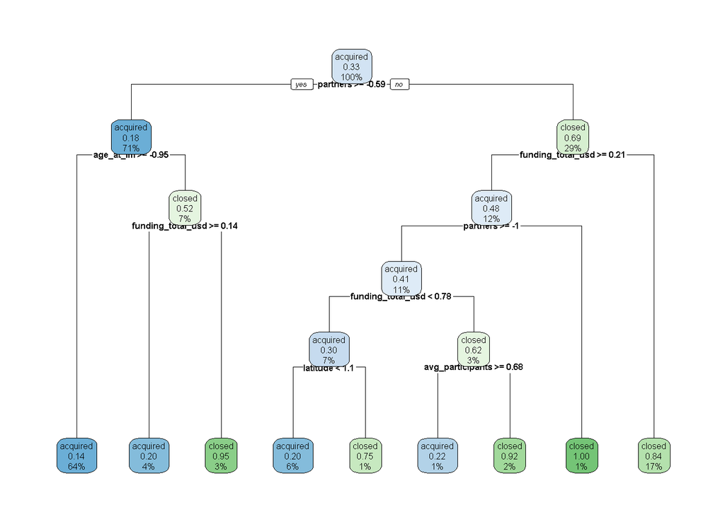

```r
options(repr.plot.width = 30, repr.plot.height = 20)
rpart.plot(tree_model, yesno = T, cex=0.5)
```

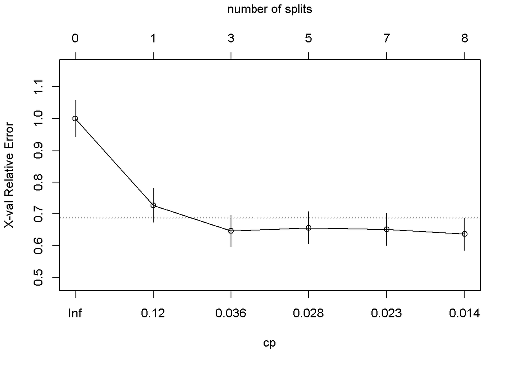

```r
plotcp(tree_model, upper = "splits")
```

Variables importance

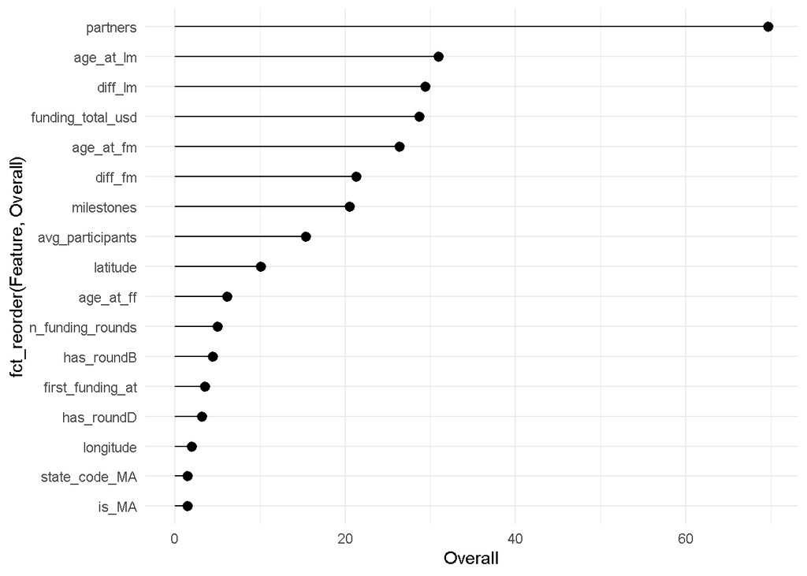

```r
tree_model$variable.importance |>
  data.frame() |> rownames_to_column(var = "Feature") %>%
  dplyr :: rename(Overall = "tree_model.variable.importance") |> ggplot(aes(x = fct_reorder(Feature, Overall), y = Overall)) +
  geom_pointrange(aes(ymin = 0, ymax = Overall)) + theme_minimal() + coord_flip()
```

**Features selected from D.tree classifier**

```r
dsc_features <- f1_data |> dplyr::select(c("latitude", "longitude","first_funding_at", "age_at_ff" , "age_at_fm", "partners" , "n_funding_rounds" , "funding_total_usd", "milestones" )  )
```

**D.tree data**

```r
dsc_data <- cbind(dsc_features, f1_data$status)
dsc_data <- dsc_data |> rename( "status" = "f1_data$status")
str(dsc_data)
```

```
## 'data.frame':    865 obs. of  10 variables:
##  $ latitude         : num  1.077 -0.319 -1.501 -0.296 -0.171 ...
##  $ longitude        : num  1.492 -0.835 -0.616 -0.838 -0.855 ...
##  $ first_funding_at : num  0.686 -1.074 1.127 -1.074 1.127 ...
##  $ age_at_ff        : num  -0.0406 1.1127 -0.5282 0.3131 -0.9423 ...
##  $ age_at_fm        : num  0.667 1.494 -0.471 1.139 -0.974 ...
##  $ partners         : num  -0.658 0.152 -0.388 -0.388 -0.793 ...
##  $ n_funding_rounds : num  0.466 1.176 -0.955 0.466 -0.245 ...
##  $ funding_total_usd: num  -1.658 0.945 -0.579 0.944 -0.965 ...
##  $ milestones       : num  0.871 -0.626 0.123 -0.626 -0.626 ...
##  $ status           : Factor w/ 2 levels "acquired","closed": 1 1 1 1 2 2 1 1 1 1 ...
```

# Data splitting

## Train- Test Data split

- Using Stratified k-folds

```r
# Load necessary library
library(caret)

# Define the number of folds
num_folds <- 5

# Perform stratified K-fold cross-validation
folds <- createFolds(dsc_data$status, k = num_folds, list = TRUE, returnTrain = FALSE)

# Initialize a list to store results
results <- list()

# Iterate through each fold
for (i in seq_along(folds)) {
  # Get the indices of the test set for the current fold
  test_indices <- unlist(folds[i])

  # Create the training and testing sets for the current fold
  train_data <- dsc_data[-test_indices, ]
  test_data <- dsc_data[test_indices, ]

  # Perform some analysis/training with train_data
  # (e.g., train a model and evaluate it on test_data)

  # Store the test_data or the results of the evaluation
  results[[i]] <- list(train_data = train_data, test_data = test_data)

  # Optionally, print or log the size of train and test sets
  cat("Fold", i, ": Train set size =", nrow(train_data), ", Test set size =", nrow(test_data), "\n")
}
```

```
## Fold 1 : Train set size = 693 , Test set size = 172
## Fold 2 : Train set size = 692 , Test set size = 173
## Fold 3 : Train set size = 691 , Test set size = 174
## Fold 4 : Train set size = 691 , Test set size = 174
## Fold 5 : Train set size = 693 , Test set size = 172
```

```r
# Optionally, combine all test_data for further analysis
all_test_data <- do.call(rbind, lapply(results, function(x) x$test_data))
cat("Total test set size after combining all folds =", nrow(all_test_data), "\n")
```

```
## Total test set size after combining all folds = 865
```

```r
cv_data<- rbind(train_data, test_data)
str(cv_data)
```

```
## 'data.frame':    865 obs. of  10 variables:
##  $ latitude         : num  1.077 -0.319 -1.501 -0.273 -0.277 ...
##  $ longitude        : num  1.492 -0.835 -0.616 -0.84 -0.839 ...
##  $ first_funding_at : num  0.686 -1.074 1.127 -0.634 -0.634 ...
##  $ age_at_ff        : num  -0.0406 1.1127 -0.5282 0.8799 -0.2526 ...
##  $ age_at_fm        : num  0.6665 1.4944 -0.4709 0.7849 0.0755 ...
##  $ partners         : num  -0.658 0.152 -0.388 -0.658 -0.253 ...
##  $ n_funding_rounds : num  0.466 1.176 -0.955 -0.955 0.466 ...
##  $ funding_total_usd: num  -1.6577 0.9451 -0.579 0.0112 0.7037 ...
##  $ milestones       : num  0.871 -0.626 0.123 -0.626 0.123 ...
##  $ status           : Factor w/ 2 levels "acquired","closed": 1 1 1 2 1 1 1 2 1 1 ...
```

# **D.tree classifier Models**

## **Decision Tree**

```r
library(DAAG)
library(party)
```

```r
library(rpart)
library(rpart.plot)
library(mlbench)
library(caret)
library(pROC)
library(tree)
```

#### Model

```r
set.seed(12)
Ds_Model <- train_data |> rpart(status ~., data = _, method = "class")
```

#### Visualizing the results

```r
printcp(Ds_Model)
```

```
##
## Classification tree:
## rpart(formula = status ~ ., data = train_data, method = "class")
##
## Variables actually used in tree construction:
## [1] age_at_ff         age_at_fm         funding_total_usd milestones
## [5] partners
##
## Root node error: 238/693 = 0.34343
##
## n= 693
##
##         CP nsplit rel error  xerror     xstd
## 1 0.323529      0   1.00000 1.00000 0.052523
## 2 0.033613      1   0.67647 0.67647 0.046712
## 3 0.021008      2   0.64286 0.69328 0.047110
## 4 0.018908      5   0.57983 0.68908 0.047012
## 5 0.016807      7   0.54202 0.67647 0.046712
## 6 0.010000      8   0.52521 0.65966 0.046301
```

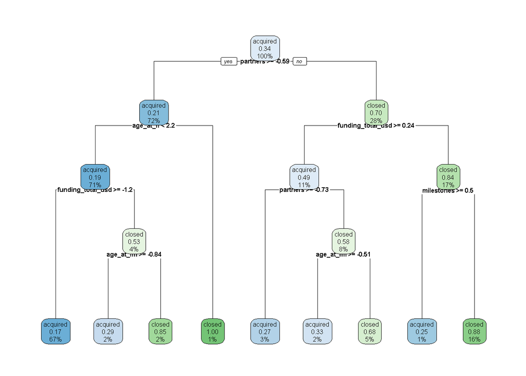

```r
options(repr.plot.width = 30, repr.plot.height = 20)
rpart.plot(Ds_Model, yesno = T, cex=0.5)
```

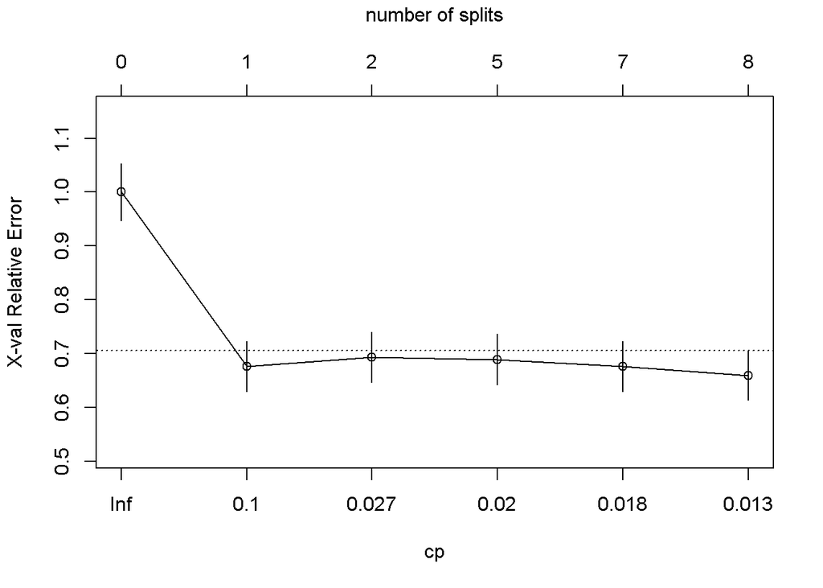

```r
plotcp(Ds_Model, upper = "splits")
```

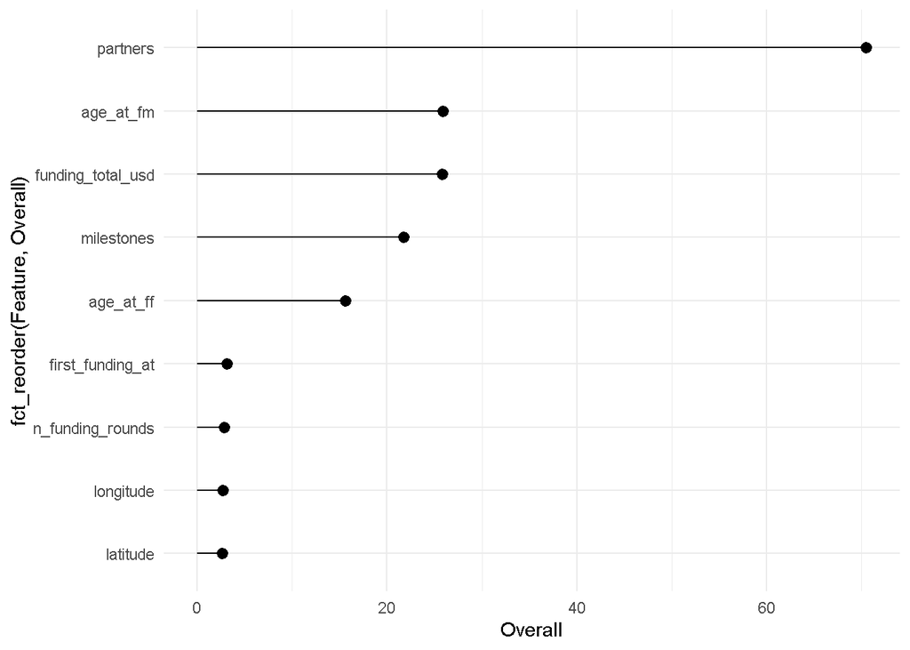

```r
Ds_Model$variable.importance |>
  data.frame() |> rownames_to_column(var = "Feature") %>%
  dplyr :: rename(Overall = 'Ds_Model.variable.importance') |> ggplot(aes(x = fct_reorder(Feature, Overall), y = Overall)) +
  geom_pointrange(aes(ymin = 0, ymax = Overall)) + theme_minimal() + coord_flip()
```

#### Evaluation

```r
library(caret)
library(ggplot2)
library(gridExtra)
DSC_Model_p <- predict(Ds_Model, newdata=cv_data, type= "class" )
cm1<- confusionMatrix(cv_data$status, reference = DSC_Model_p)

cm1
```

```
## Confusion Matrix and Statistics
##
##           Reference
## Prediction acquired closed
##   acquired      529     39
##   closed        123    174
##
##                Accuracy : 0.8127
##                  95% CI : (0.7851, 0.8382)
##     No Information Rate : 0.7538
##     P-Value [Acc > NIR] : 2.072e-05
##
##                   Kappa : 0.5546
##
##  Mcnemar's Test P-Value : 6.980e-11
##
##             Sensitivity : 0.8113
##             Specificity : 0.8169
##          Pos Pred Value : 0.9313
##          Neg Pred Value : 0.5859
##              Prevalence : 0.7538
##          Detection Rate : 0.6116
##    Detection Prevalence : 0.6566
##       Balanced Accuracy : 0.8141
##
##        'Positive' Class : acquired
##
```

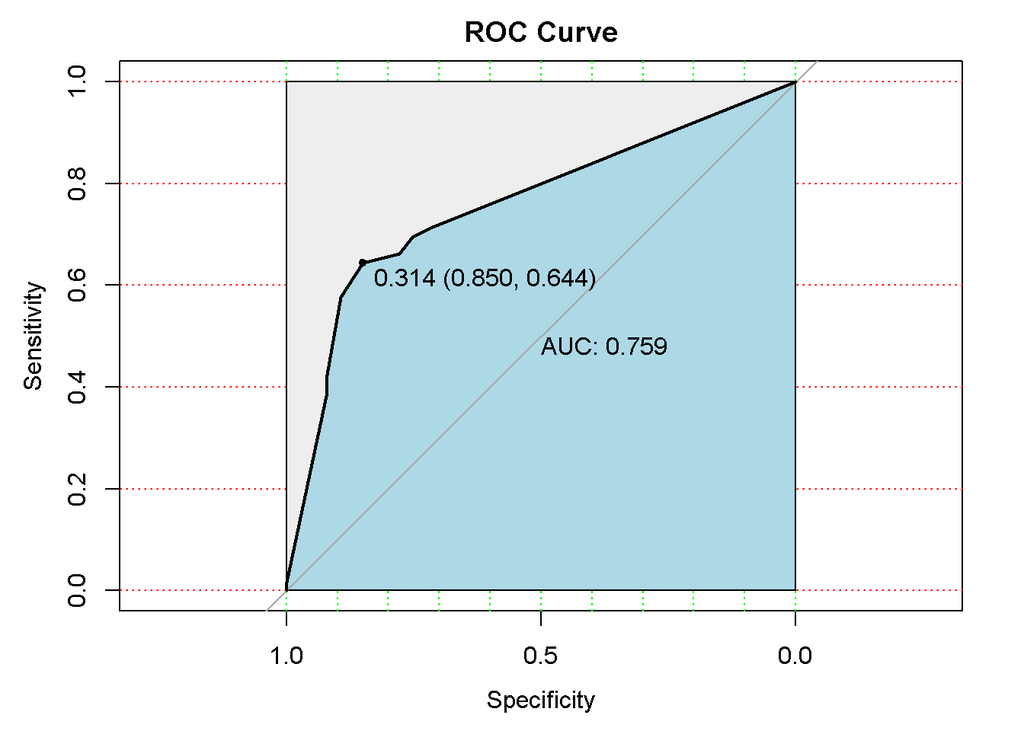

```r
# ROC curve
pred_probs <- predict(Ds_Model, newdata = test_data, type = "prob")[,2]
roc_data <- roc(test_data$status, pred_probs)
# Plot the ROC curve
plot(roc_data,
     print.auc = TRUE,
     auc.polygon = TRUE,
     grid = c(0.1, 0.2),
     grid.col = c("green", "red"),
     max.auc.polygon = TRUE,
     auc.polygon.col = "lightblue",
     print.thres = TRUE,
     main = 'ROC Curve')
```

```r
str(train_data)
```

```
## 'data.frame':    693 obs. of  10 variables:
##  $ latitude         : num  1.077 -0.319 -1.501 -0.273 -0.277 ...
##  $ longitude        : num  1.492 -0.835 -0.616 -0.84 -0.839 ...
##  $ first_funding_at : num  0.686 -1.074 1.127 -0.634 -0.634 ...
##  $ age_at_ff        : num  -0.0406 1.1127 -0.5282 0.8799 -0.2526 ...
##  $ age_at_fm        : num  0.6665 1.4944 -0.4709 0.7849 0.0755 ...
##  $ partners         : num  -0.658 0.152 -0.388 -0.658 -0.253 ...
##  $ n_funding_rounds : num  0.466 1.176 -0.955 -0.955 0.466 ...
##  $ funding_total_usd: num  -1.6577 0.9451 -0.579 0.0112 0.7037 ...
##  $ milestones       : num  0.871 -0.626 0.123 -0.626 0.123 ...
##  $ status           : Factor w/ 2 levels "acquired","closed": 1 1 1 2 1 1 1 2 1 1 ...
```

##** Logistic reg**

```r
Log_Model <- glm(status ~ .,
             data = train_data,
             family = binomial)

# View the summary of the model
summary(Log_Model)
```

```
##
## Call:
## glm(formula = status ~ ., family = binomial, data = train_data)
##
## Coefficients:
##                   Estimate Std. Error z value Pr(>|z|)
## (Intercept)       -0.97356    0.11062  -8.801  < 2e-16 ***
## latitude          -0.10280    0.10250  -1.003  0.31589
## longitude         -0.05564    0.10351  -0.538  0.59091
## first_funding_at   0.02986    0.11595   0.257  0.79681
## age_at_ff          0.34461    0.13030   2.645  0.00818 **
## age_at_fm         -0.30969    0.12699  -2.439  0.01474 *
## partners          -0.97994    0.20264  -4.836 1.33e-06 ***
## n_funding_rounds   0.06542    0.11657   0.561  0.57467
## funding_total_usd -0.59029    0.12944  -4.560 5.11e-06 ***
## milestones        -0.34861    0.12866  -2.710  0.00674 **
## ---
## Signif. codes:  0 '***' 0.001 '**' 0.01 '*' 0.05 '.' 0.1 ' ' 1
##
## (Dispersion parameter for binomial family taken to be 1)
##
##     Null deviance: 891.60  on 692  degrees of freedom
## Residual deviance: 689.64  on 683  degrees of freedom
## AIC: 709.64
##
## Number of Fisher Scoring iterations: 5
```

These predictors significantly contribute to the prediction of the status. The coefficients for these significant predictors indicate the direction and magnitude of their effect on the log-odds of the status being 1. The predictors with non-significant p-values do not contribute significantly to the model according to this analysis.